# openQA Documentation

# 1 Getting Started

## 1.1 Introduction

openQA is an automated test tool that makes it possible to test the whole installation process of an operating system. It uses virtual machines to reproduce the process, check the output (both serial console and screen) in every step and send the necessary keystrokes and commands to proceed to the next. openQA can check whether the system can be installed, whether it works properly in 'live' mode, whether applications work or whether the system responds as expected to different installation options and commands.

Even more importantly, openQA can run several combinations of tests for every revision of the operating system, reporting the errors detected for each combination of hardware configuration, installation options and variant of the operating system.

openQA is free software released under the [GPLv2 license](http://www.gnu.org/licenses/gpl-2.0.html). The source code and documentation are hosted in the [os-autoinst organization on GitHub](https://github.com/os-autoinst).

This document describes the general operation and usage of openQA. The main goal is to provide a general overview of the tool, with all the information needed to become a happy user.

For a quick start, if you already have an openQA instance available you can refer to the section Cloning existing jobs - openqa-clone-job directly to trigger a new test based on already existing job. For a quick installation refer directly to Quick bootstrapping under openSUSE or Container based setup.

For the installation of openQA in general see the Installation Guide, as a user of an existing instance see the Users Guide. More advanced topics can be found in other documents. All documents are also available in the [official repository](https://github.com/os-autoinst/openQA).

## 1.2 Architecture

Although the project as a whole is referred to as openQA, there are in fact several components that are hosted in separate repositories as shown in the following figure.

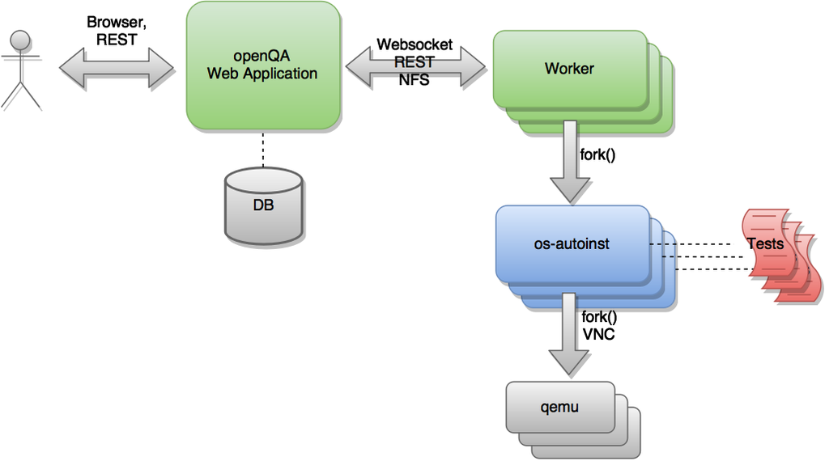

openQA architecture

The heart of the test engine is a standalone application called 'os-autoinst' (blue). In each execution, this application creates a virtual machine and uses it to run a set of test scripts (red). 'os-autoinst' generates a video, screenshots and a JSON file with detailed results.

'openQA' (green) on the other hand provides a web based user interface and infrastructure to run 'os-autoinst' in a distributed way. The web interface also provides a JSON based REST-like API for external scripting and for use by the worker program. Workers fetch data and input files from openQA for os-autoinst to run the tests. A host system can run several workers. The openQA web application takes care of distributing test jobs among workers. Web application and workers can run on the same machine as well as connected via network on multiple machines within the same network or distributed. Running the web application as well as the workers in the cloud is perfectly possible.

Note that the diagram shown above is simplified. There exists a more sophisticated version which is more complete and detailed. (The diagram can be edited via its underlying GraphML file.)

## 1.3 Basic concepts

### 1.3.1 Glossary

The following terms are used within the context of openQA:

**test modules** : an individual test case in a single perl module file, e.g. "sshxterm". If not further specified a test module is denoted with its "short name" equivalent to the filename including the test definition. The "full name" is composed of the *test group* (TBC), which itself is formed by the top-folder of the test module file, and the short name, e.g. "x11-sshxterm" (for x11/sshxterm.pm)

**test suite** : a collection of *test modules*, e.g. "textmode". All *test modules* within one *test suite* are run serially

**job** : one run of individual test cases in a row denoted by a unique number for one instance of openQA, e.g. one installation with subsequent testing of applications within gnome

**test run** : equivalent to *job*

**test result** : the result of one job, e.g. "passed" with the details of each individual *test module*

**test step** : the execution of one *test module* within a *job*

**distri** : a test distribution but also sometimes referring to a *product* (CAUTION: ambiguous, historically a "GNU/Linux distribution"), composed of multiple *test modules* in a folder structure that compose *test suites*, e.g. "opensuse" (test distribution, short for "os-autoinst-distri-opensuse")

**needles** : reference images to assert whether what is on the screen matches expectations and to locate elements on the screen the tests needs to interact with (e.g. to locate a button to click on it)

**product** : the main "system under test" (SUT), e.g. "openSUSE", also called "Medium Types" in the web interface of openQA

**job group** : equivalent to *product*, used in context of the webUI

**version** : one version of a *product*, don't confuse with *builds*, e.g. "Tumbleweed"

**flavor** : a specific variant of a *product* to distinguish differing variants, e.g. "DVD"

**arch** : an architecture variant of a *product*, e.g. "x86_64"

**machine** : additional variant of machine, e.g. used for "64bit", "uefi", etc.

**scenario** : A composition of `<distri>-<version>-<flavor>-<arch>-<test_suite>@<machine>`, e.g. `openSUSE-Tumbleweed-DVD-x86_64-gnome@64bit`, nicknamed *koala*

**build** : Different versions of a product as tested, can be considered a "sub-version" of *version*, e.g. "Build1234"; **CAUTION:** ambiguity: either with the prefix "Build" included or not

### 1.3.2 Jobs

One of the most important features of openQA is that it can be used to test several combinations of actions and configurations. For every one of those combinations, the system creates a virtual machine, performs certain steps and returns an overall result. Every one of those executions is called a 'job'. Every job is labeled with a numeric identifier and has several associated 'settings' that will drive its behavior.

A job goes through several states. Here is (an incomplete list) of these states:

- **scheduled** Initial state for newly created jobs. Queued for future execution.
- **setup**/**running**/**uploading** In progress.
- **cancelled** The job was explicitly cancelled by the user or was replaced by a clone (see below) and the worker has not acknowledged the cancellation yet.
- **done** The worker acknowledged that the execution finished or the web UI considers the job as abandoned by the worker.

Jobs in the final states 'cancelled' and 'done' have typically gone through a whole sequence of steps (called 'testmodules') each one with its own result. But in addition to those partial results, a finished job also provides an overall result from the following list.

- **none** For jobs that have not reached one of the final states.
- **passed** No critical check failed during the process. It does not necessarily mean that all testmodules were successful or that no single assertion failed.
- **failed** At least one assertion considered to be critical was not satisfied at some point.
- **softfailed** At least one known, non-critical issue has been found. That could be that workaround needles are in place, a softfailure has been recorded explicitly via `record_soft_failure` (from os-autoinst) or a job failure has been ignored explicitly via a job label.
- **timeout_exceeded** The job was aborted because `MAX_JOB_TIME` or `MAX_SETUP_TIME` has been exceeded, see Changing timeout for details.
- **skipped** Dependencies failed so the job was not started.
- **obsoleted** The job was superseded by scheduling a new product.
- **parallel_failed**/**parallel_restarted** The job could not continue because a job which is supposed to run in parallel failed or was restarted.
- **user_cancelled**/**user_restarted** The job was cancelled/restarted by the user.
- **incomplete** The test execution failed due to an unexpected error, e.g. the network connection to the worker was lost.

Sometimes, the reason of a failure is not an error in the tested operating system itself, but an outdated test or a problem in the execution of the job for some external reason. In those situations, it makes sense to re-run a given job from the beginning once the problem is fixed or the tests have been updated. This is done by means of 'cloning'. Every job can be superseded by a clone which is scheduled to run with exactly the same settings as the original job. If the original job is still not in 'done' state, it's cancelled immediately. From that point in time, the clone becomes the current version and the original job is considered outdated (and can be filtered in the listing) but its information and results (if any) are kept for future reference.

### 1.3.3 Needles

One of the main mechanisms for openQA to know the state of the virtual machine is checking the presence of some elements in the machine's 'screen'. This is performed using fuzzy image matching between the screen and the so called 'needles'. A needle specifies both the elements to search for and a list of tags used to decide which needles should be used at any moment.

A needle consists of a full screenshot in PNG format and a json file with the same name (e.g. foo.png and foo.json) containing the associated data, like which areas inside the full screenshot are relevant or the mentioned list of tags.

```json
{
   "area" : [
      {
         "xpos" : INTEGER,
         "ypos" : INTEGER,
         "width" : INTEGER,
         "height" : INTEGER,
         "type" : ( "match" | "ocr" | "exclude" ),
         "match" : INTEGER, // 0-100. similarity percentage
         "click_point" : CLICK_POINT, // Optional click point
      },
      ...
   ],
   "tags" : [
      STRING, ...
   ]
}
```

#### 1.3.3.1 Areas

There are three kinds of areas:

- **Regular areas** define relevant parts of the screenshot. Those must match with at least the specified similarity percentage. Regular areas are displayed as green boxes in the needle editor and as green or red frames in the needle view (green for matching areas, red for non-matching ones).
- **OCR areas** also define relevant parts of the screenshot. However, an OCR algorithm is used for matching. In the needle editor OCR areas are displayed as orange boxes. To turn a regular area into an OCR area within the needle editor, double click the concerning area twice. Note that such needles are only rarely used.
- **Exclude areas** can be used to ignore parts of the reference picture. In the needle editor exclude areas are displayed as red boxes. To turn a regular area into an exclude area within the needle editor, double click the concerning area. In the needle view exclude areas are displayed as gray boxes.

#### 1.3.3.2 Click points

Each regular match area in a needle can optionally contain a **click point**. This is used with the `testapi::assert_and_click` function to match GUI elements such as buttons and then click inside the matched area.

```json
{
  "xpos" : INTEGER, // Relative coordinates inside the match area
  "ypos" : INTEGER,
  "id" : STRING,    // Optional
}
```

Each click point can have an `id`, and if a needle contains multiple click points you must pass it to `testapi::assert_and_click` to select which click point to use.

### 1.3.4 Configuration

The different components of openQA read their configuration from the following files:

- `openqa.ini`, `openqa.ini.d/*.ini`: These files are the "web UI" config. Services providing the web interface and related services such as the scheduler are configured via these files.
- `database.ini`, `database.ini.d/*.ini`: These files are also used by services providing the web interface and related services such as the scheduler. It is used to configure how those services connect to the database.
- `workers.ini`, `workers.ini.d/*.ini`: These files are used to configure the openQA worker including its additional cache service.
- `client.conf`, `client.conf.d/*.conf`: These files contain API credentials and are used by the openQA worker and other tooling such as `openqa-cli` and `openqa-clone-job` to authenticate with the web interface. One API key/secret can be configured per web UI host.

If these files are not present, defaults are used.

Example configuration files are installed under `/usr/share/doc/openqa/examples` and in the [Git repository under `etc/openqa`](https://github.com/os-autoinst/openQA/tree/master/etc/openqa). Continue reading the next sections for where you can place the actual configuration files and the possibility of creating drop-in configuration files.

#### 1.3.4.1 Locations

All configuration files can be placed under `/etc/openqa`, e.g. `/etc/openqa/openqa.ini`. That is where administrators are expected to store system-wide configuration.

Configuration files are also looked up under `/usr/etc/openqa` where a package maintainer can place default values deviating from upstream defaults.

The client configuration can also be put under `~/.config/openqa/client.conf`.

For development, check out the section about customizing the configuration directory.

#### 1.3.4.2 Drop-in configurations

It is recommended to split the configuration into multiple files and store these "drop-in" configuration files in the `….d` sub directory, e.g. `/etc/openqa/openqa.ini.d/01-plugins.ini`. This is possible for all config files, e.g. `/etc/openqa/workers.ini.d/01-bare-metal-instances.ini` and `/etc/openqa/client.conf.d/01-internal.conf` can be created as well to configure workers and API credentials. This works also on other locations, e.g. `/usr/etc/openqa/openqa.ini.d/01-plugins.ini` will be found as well. Settings from drop-in configurations override settings from the main config files. Drop-in configurations are read in alphabetical order and subsequent files override settings from preceding ones.

### 1.3.5 Access management

Some actions in openQA require special privileges. openQA provides authentication through [openID](http://en.wikipedia.org/wiki/OpenID). By default, openQA is configured to use the openSUSE openID provider, but it can very easily be configured to use any other valid provider. Every time a new user logs into an instance, a new user profile is created. That profile only contains the openID identity and two flags used for access control:

- **operator** Means that the user is able to manage jobs, performing actions like creating new jobs, cancelling them, etc.
- **admin** Means that the user is able to manage users (granting or revoking operator and admin rights) as well as job templates and other related information (see the the corresponding section).

Many of the operations in an openQA instance are not performed through the web interface but using the REST-like API. The most obvious examples are the workers and the scripts that fetch new versions of the operating system and schedule the corresponding tests. Those clients must be authorized by an operator using an [API key](http://en.wikipedia.org/wiki/Application_programming_interface_key) with an associated shared secret.

For that purpose, users with the operator flag have access in the web interface to a page that allows them to manage as many API keys as they may need. For every key, a secret is automatically generated. The user can then configure the workers or any other client application to use whatever pair of API key and secret owned by him. Any client to the REST-like API using one of those API keys will be considered to be acting on behalf of the associated user. So the API key not only has to be correct and valid (not expired), it also has to belong to a user with operator rights.

For more insights about authentication, authorization and the technical details of the openQA security model, refer to the [detailed blog post](http://lizards.opensuse.org/2014/02/28/about-openqa-and-authentication/) about the subject by the openQA development team.

### 1.3.6 Job groups

A job can belong to a job group. Those job groups are displayed on the index page when there are recent test results in these job groups and in the `Job` `Groups` menu on the navigation bar. From there the job group overview pages can be accessed. Besides the test results the job group overview pages provide a description about the job group and allow commenting.

Job groups have properties. These properties are mostly cleanup related. The configuration can be done in the operators menu for job groups.

It is also possible to put job groups into categories. The nested groups will then inherit properties from the category. The categories are meant to combine job groups with common builds so test results for the same build can be shown together on the index page.

### 1.3.7 Cleanup

openQA automatically archives and deletes data that it considers "old" based on different settings. For example old jobs and assets are deleted at some point. The settings can be adjusted on job-group-level and in the configuration file You can read the Cleanup section for details.

## 1.4 Using the client script

Just as the worker uses an API key+secret every user of the `client script` must do the same. The same API key+secret as previously created can be used or a new one created over the webUI.

The personal configuration should be stored in a file `~/.config/openqa/client.conf` in the same format as previously described for the `client.conf`, i.e. sections for each machine, e.g. `localhost`.

## 1.5 Testing openSUSE or Fedora

An easy way to start using openQA is to start testing openSUSE or Fedora as they have everything setup and prepared to ease the initial deployment. If you want to play deeper, you can configure the whole openQA manually from scratch, but this document should help you to get started faster.

### 1.5.1 Getting tests

You can point `CASEDIR` and `NEEDLES_DIR` to Git repositories. openQA will check out those repositories automatically and no manual setup is needed.

Otherwise you will need to clone tests and needles manually. For this, clone a subdirectory under `/var/lib/openqa/tests` for each test distribution you need, e.g. `/var/lib/openqa/tests/opensuse` for openSUSE tests. The repositories will be kept up-to-date if `git_auto_update` is enabled in the web UI configuration (which is the default). The updating is triggered when new tests are scheduled. For a periodic update (to avoid getting too far behind) you can enable the systemd unit `openqa-enqueue-git-auto-update.timer`.

You can get openSUSE tests and needles from [GitHub](https://github.com/os-autoinst/os-autoinst-distri-opensuse). To make it easier, you can just run `/usr/share/openqa/script/fetchneedles`. It will download tests and needles to the correct location with the correct permissions.

Fedora's tests are also in [git](https://pagure.io/fedora-qa/os-autoinst-distri-fedora). To use them, you may do:

```bash
cd /var/lib/openqa/share/tests
mkdir fedora
cd fedora
git clone https://pagure.io/fedora-qa/os-autoinst-distri-fedora.git
cd ..
chown -R geekotest fedora/
```

### 1.5.2 Getting openQA configuration

To get everything configured to actually run the tests, there are plenty of options to set in the admin interface. If you plan to test openSUSE Factory, using tests mentioned in the previous section, the easiest way to get started is the following command:

```bash
/var/lib/openqa/share/tests/opensuse/products/opensuse/templates [--apikey API_KEY] [--apisecret API_SECRET]
```

This will load some default settings that were used at some point of time in openSUSE production openQA. Therefore those should work reasonably well with openSUSE tests and needles. This script uses `/usr/share/openqa/script/openqa-load-templates`, consider reading its help page (`--help`) for documentation on possible extra arguments.

For Fedora, similarly, you can call:

```bash
/var/lib/openqa/share/tests/fedora/fifloader.py -c -l templates.fif.json templates-updates.fif.json
```

For this to work you need to have a `client.conf` with API key and secret, because fifloader doesn't support setting them on the command line. See the openQA client section for more details on this. Also see the docstring of `fifloader.py` for details on the alternative template format Fedora uses.

Some Fedora tests require special hard disk images to be present in `/var/lib/openqa/share/factory/hdd/fixed`. The `createhdds.py` script in the createhdds repository can be used to create these. See the documentation in that repo for more information.

### 1.5.3 Adding a new ISO to test

To start testing a new ISO put it in `/var/lib/openqa/share/factory/iso` and call the following commands:

```bash
# Run the first test
openqa-cli api -X POST isos \
         ISO=openSUSE-Factory-NET-x86_64-Build0053-Media.iso \
         DISTRI=opensuse \
         VERSION=Factory \
         FLAVOR=NET \
         ARCH=x86_64 \
         BUILD=0053
```

If your openQA is not running on port 80 on 'localhost', you can add option `--host=http://otherhost:9526` to specify a different port or host.

> **WARNING:** Use only the ISO filename in the 'client' command. You must place the file in `/var/lib/openqa/share/factory/iso`. You cannot place the file elsewhere and specify its path in the command. However, openQA also supports a remote-download feature of assets from trusted domains.

For Fedora, a sample run might be:

```bash
# Run the first test
openqa-cli api -X POST isos \
         ISO=Fedora-Everything-boot-x86_64-Rawhide-20160308.n.0.iso \
         DISTRI=fedora \
         VERSION=Rawhide \
         FLAVOR=Everything-boot-iso \
         ARCH=x86_64 \
         BUILD=Rawhide-20160308.n.0
```

More details on triggering tests can also be found in the Users Guide.

## 1.6 Pitfalls

Take a look at Documented Pitfalls.

# 2 Installing

## 2.1 Introduction

openQA is an automated test tool that makes it possible to test the whole installation process of an operating system. It is free software released under the [GPLv2 license](http://www.gnu.org/licenses/gpl-2.0.html). The source code and documentation are hosted in the [os-autoinst organization on GitHub](https://github.com/os-autoinst).

This document provides the information needed to install and setup the tool, as well as information useful for everyday administration of the system. It is assumed that the reader is already familiar with the concepts of openQA and has already read the Getting Started Guide, also available at the [official repository](https://github.com/os-autoinst/openQA).

Continue with the next section Container based setup to setup a simple, ready-to-use container based openQA instance which is useful for a single user setup. For a quick bootstrapping under openSUSE go to Quick bootstrapping. Else, continue with the more advanced section about Custom installation. For a setup suitable to develop openQA itself, have a look at the Development setup section.

## 2.2 Container based setup

openQA is provided in containers. Multiple variants exist.

### 2.2.1 Single-instance container

The easiest and quickest way to spawn a single instance of openQA with a single command line using the `podman` container engine is the following:

```bash
podman run --name openqa --device /dev/kvm -p 1080:80 -p 1443:443 --rm -it \
  registry.opensuse.org/devel/openqa/containers/openqa-single-instance
```

Once the startup has finished, the web UI is accessible via http://localhost:1080 or https://localhost:1443.

#### 2.2.1.1 How to run a test with single-instance container in 5 minutes

[video not shown]

#### 2.2.1.2 Triggering and cloning existing jobs within single-instance container

For triggering new tests or cloning existing ones you can use `openqa-cli` which is conveniently available inside the container. The quickest and easiest way would be to enter an interactive session inside the already running single-instance container. You can spawn a new shell via:

```bash
podman exec -ti openqa /bin/bash
```

From there, you can trigger a new job or clone an existing one, e.g.:

```bash
openqa-cli schedule --monitor async=1 \
    SCENARIO_DEFINITIONS_YAML_FILE=https://raw.githubusercontent.com/os-autoinst/os-autoinst-distri-example/refs/heads/main/scenario-definitions.yaml \
    DISTRI=example VERSION=0 FLAVOR=DVD ARCH=x86_64 \
    TEST=simple_boot _GROUP_ID=0 BUILD=test \
    CASEDIR=https://github.com/os-autoinst/os-autoinst-distri-example.git \
    PRODUCTDIR=. \
    NEEDLES_DIR=%%CASEDIR%%/needles

openqa-clone-job https://openqa.opensuse.org/tests/1
```

More details on triggering tests can also be found in the Users Guide.

You can also run the container and directly clone tests, e.g.:

```bash
podman run -e skip_suse_specifics= -e skip_suse_tests= \
 --name openqa --device /dev/kvm -p 1080:80 -p 1443:443 --rm \
 -it registry.opensuse.org/devel/openqa/containers/openqa-single-instance \
 https://openqa.opensuse.org/tests/1
```

The `skip_suse_specifics=` and `skip_suse_tests=` options ensure the test files and needles required for openSUSE/SUSE tests are downloaded. Refer to the example video above and the get testing section for more details.

### 2.2.2 Separate web UI and worker containers

As an alternative also separate containers are provided for both the web UI and worker.

For example the web UI container can be pulled and started using the `podman` container engine:

```bash
podman run -p 1080:80 -p 1443:443 --rm -it registry.opensuse.org/devel/openqa/containers16.0/openqa_webui:latest
```

The worker container can be pulled and started with:

```bash
podman run --rm -it registry.opensuse.org/devel/openqa/containers16.0/openqa_worker:latest
```

### 2.2.3 Custom configuration for containers

To supply a custom openQA config file, use the `-v` parameter. This also works for the database config file. Note that if a custom database config file is specified, no database is launched within the container. By default, the web UI container uses the self-signed certificate that comes with Mojolicious. To supply a different certificate, use the `-v` parameter. Example for running openQA with a custom config and certificate:

```bash
podman run -p 1080:80 -p 1443:443 \
  -v ./container/webui/test-cert.pem:/etc/apache2/ssl.crt/server.crt:z \
  -v ./container/webui/test-key.pem:/etc/apache2/ssl.key/server.key:z \
  -v ./container/webui/test-cert.pem:/etc/apache2/ssl.crt/ca.crt:z \
  -v ./container/webui/conf/openqa.ini:/data/conf/openqa.ini:z \
  --rm -it registry.opensuse.org/devel/openqa/containers16.0/openqa_webui:latest
```

The same works for the workers container where you most likely want to to supply `workers.ini` and `client.conf`:

```bash
podman run \
  -v ./container/worker/conf/workers.ini:/data/conf/workers.ini:z \
  -v ./container/worker/conf/client.conf:/data/conf/client.conf:z \
  --rm -it registry.opensuse.org/devel/openqa/containers16.0/openqa_worker:latest
```

This examples assume the working directory is an openQA checkout. To avoid doing a checkout, you can also grab the config files from the webui/conf and worker/conf directory listings on GitHub.

To learn more about how to run workers check out the Run openQA workers section.

For creating a first test job, check out the Triggering tests section. Note that the commands mentioned there can also be invoked within a container, e.g.:

```bash
podman run \
   --rm -it registry.opensuse.org/devel/openqa/containers16.0/openqa_webui:latest \
   openqa-cli --help
```

Check out the containerized setup section for more details.

Take a look at [openSUSE's registry](https://registry.opensuse.org/cgi-bin/cooverview?srch_term=project%3Ddevel%3AopenQA) for all available container images.

### 2.2.4 Kubernetes

Find a guide and the helm charts for Kubernetes deployment of openQA in [Helm README](https://github.com/os-autoinst/openQA/blob/master/container/helm/README.md).

## 2.3 Quick bootstrapping under openSUSE

To quickly get a working openQA installation, you can use the openqa-bootstrap script. It essentially automates the steps mentioned in the Custom installation section.

### 2.3.1 Directly on your machine

On openSUSE Leap and openSUSE Tumbleweed to setup openQA on your machine simply download and execute the openqa-bootstrap script as root - it will do the rest for you:

```bash
curl -s https://raw.githubusercontent.com/os-autoinst/openQA/master/script/openqa-bootstrap | bash -x
```

The script is also available from an openSUSE package to install from:

```bash
zypper in openQA-bootstrap
/usr/share/openqa/script/openqa-bootstrap
```

openQA-bootstrap supports to immediately clone an existing job simply by supplying `openqa-clone-job` parameters directly for a quickstart:

```bash
/usr/share/openqa/script/openqa-bootstrap --from openqa.opensuse.org 12345 SCHEDULE=tests/boot/boot_to_desktop,tests/x11/kontact
```

The above command will bootstrap an openQA installation and immediately afterwards start a local test job clone from a test job from a remote instance with optional, overridden parameters. More information about `openqa-clone-job` can be found in Cloning existing jobs - openqa-clone-job.

You can also run `openqa-bootstrap` repeatedly. For example when you stop a container and the openQA daemons and database are stopped, calling `openqa-bootstrap start` will start necessary daemons again.

### 2.3.2 openQA in a browser

You can try out `openqa-bootstrap` in a container environment like [GitHub Codespaces](https://docs.github.com/en/codespaces).

On [GitHub openQA](https://github.com/os-autoinst/openQA), click on the "Code" button and select "Codespaces". Just click on the plus sign to create a new Codespace. Or use [this link](https://codespaces.new/os-autoinst/openQA?quickstart=1) as a quickstart to resume existing instances or create new ones.

It will run `openqa-bootstrap` in the background. If the codespace environment is ready, open a new VSCode terminal and type

```
tail -f /var/log/openqa-bootstrap.log
```

The Web UI instance can be opened as soon as you get a popup that there is a webserver available on port 80.

You can now use `openqa-clone-job` to run jobs in this instance.

##### 2.3.2.0.1 After stopping and resuming a codespace instance, run

```bash
/usr/share/openqa/script/openqa-bootstrap start
```

to start the openQA daemons again.

Be sure to delete codespace instances if you don't use them anymore, as even stopped instances will consume storage of your monthly limit.

### 2.3.3 openQA in a container

You can also setup a systemd-nspawn container with openQA with the following commands. and you need to have no application listening on port 80 yet because the container will share the host system's network stack.

```bash
zypper in openQA-bootstrap
/usr/share/openqa/script/openqa-bootstrap-container

systemd-run -tM openqa1 /bin/bash # start a shell in the container
```

### 2.3.4 openQA in a virtual machine

You can also set up a ready-to-use **openQA** instance as a virtual machine in your computer.

The images are available directly from the [o3](https://openqa.opensuse.org) site. Download the HDD image `opensuse-Tumbleweed-x86_64@uefi-4G-<…>.qcow2` (~3.2 GB) from the *Assets* in the test scenario [openqa_install+publish](https://openqa.opensuse.org/tests/latest?arch=x86_64&distri=openqa&flavor=dev&machine=uefi-4G&test=openqa_install%2Bpublish&version=Tumbleweed&result=passed#downloads).

#### 2.3.4.1 The VM

The downloaded image can be used to launch a local VM from, running the *openSUSE Tumbleweed* system, a graphical user interface and a network access to your local machine's networks.

Upon starting the VM, you can login as the root user. The login credentials are available on [os-autoinst-distri-opensuse](https://github.com/os-autoinst/os-autoinst-distri-opensuse/blob/master/lib/main_common.pm) by searching for `$testapi::password`.

You can also access the VM via SSH from a console on your machine (`ssh root@<VM_IP_ADDRESS>`), after properly configuring `ssh` in the VM and your computer.

#### 2.3.4.2 The openQA instance

The system features a pre-configured **openQA** instance, which includes the web UI at http://localhost/, a worker, and a PostgreSQL database. To check the services, run on a VM terminal: `systemctl status openqa-* openqa-worker@1 postgresql`

You can access the web UI via the Firefox browser within the VM's graphical environment and log in as the default openQA Demo user. Once you have the VM's IP address, you can also access the web UI from any browser on your machine by navigating to http://<VM_IP>/.

The drop-down menu in the UI top-left corner allows you to open an *Example test* page, to run a simple test and verify the setup.

Other tests can be cloned via the VM console or an SSH session from your machine, using `openqa-clone-job`, getting the job settings from o3 and instantiating the test execution on the local VM instance (`--from openqa.opensuse.org --host localhost`; refer to the `openqa-clone-job` documentation).

## 2.4 Custom installation - repositories and procedure

Keep in mind that there can be disruptive changes between openQA versions. You need to be sure that the webui and the worker that you are using have the same version number or, at least, are compatible.

For example, the packages distributed with older versions of openSUSE Leap are not compatible with the version on Tumbleweed. And the package distributed with Tumbleweed may not be compatible with the version in the development package.

### 2.4.1 Official repositories

The easiest way to install openQA is from distribution packages.

- For SUSE Linux Enterprise (SLE), openSUSE Leap and Tumbleweed packages are available.
- For Fedora, packages are available in the official repositories for Fedora 23 and later.

### 2.4.2 Development version repository

You can find the development version of openQA in OBS in the [openQA:devel](https://build.opensuse.org/project/show/devel:openQA) repository.

To add the development repository to your system, you can use these commands.

```bash
# openSUSE Tumbleweed
zypper ar -p 95 -f 'https://download.opensuse.org/repositories/devel:openQA/openSUSE_Tumbleweed' devel_openQA

# openSUSE Leap/SLE
zypper ar -p 95 -f 'https://download.opensuse.org/repositories/devel:openQA/$releasever' devel_openQA
zypper ar -p 90 -f 'https://download.opensuse.org/repositories/devel:openQA:Leap:$releasever/$releasever' devel_openQA_Leap
```

If you installed openQA from the official repository first, you may need to change the vendor of the dependencies.

```bash
# openSUSE Tumbleweed and Leap
zypper dup --from devel_openQA --allow-vendor-change

# openSUSE Leap
zypper dup --from devel_openQA_Leap --allow-vendor-change
```

### 2.4.3 Installation

#### 2.4.3.1 Preparations on SLE

On SLE certain modules have to be enabled. Afterwards the instructions for openSUSE apply.

```bash
. /etc/os-release
SUSEConnect -p sle-module-desktop-applications/$VERSION_ID/$CPU
SUSEConnect -p sle-module-development-tools/$VERSION_ID/$CPU
SUSEConnect -p sle-we/$VERSION_ID/$CPU -r $sled_key
SUSEConnect -p PackageHub/$VERSION_ID/$CPU
```

#### 2.4.3.2 Installing openQA

You can install the main openQA server package using these commands.

```bash
# openSUSE
zypper in openQA

# Fedora
dnf install openqa openqa-httpd
```

To install the openQA worker package use the following.

```bash
# SLE/openSUSE
zypper in openQA-worker
```

Different convenience packages exist for convenience in openSUSE, for example: `openQA-local-db` to install the server including the setup of a local PostgreSQL database or `openQA-single-instance` which sets up a web UI server, a web proxy as well as a local worker. Install `openQA-client` if you only want to interact with existing, external openQA instances.

#### 2.4.3.3 Installation from sources

Installing is not required for development purposes and most components of openQA can be called directly from the repository checkout.

To install openQA from sources make sure to install all dependencies as explained in Dependencies. Then one can call

```bash
make install
```

The directory prefix can be controlled with the optional environment variable `DESTDIR`.

From then on continue with the Basic configuration.

## 2.5 System requirements

To run tests based on the default qemu backend the following hardware specifications are recommended per openQA worker instance:

- 1x CPU core with 2x hyperthreads (or 2x CPU cores)
- 8GB RAM
- 40GB HDD (preferably SSD or NVMe)

## 2.6 Basic configuration

For a local instance setup you can simply execute the script:

```bash
/usr/share/openqa/script/configure-web-proxy
```

This will automatically setup a local Apache http proxy. The script also supports NGINX and a custom port to listen on. Try `--help` to learn about the available options. Read on for more detailed setup instructions with all the details.

> **NOTE:** The web proxy might not be allowed to connect to openQA when SELinux is enabled. Therefore the `configure-web-proxy` script will automatically run `semanage boolean -m -1 httpd_can_network_connect` on SELinux systems to change that.

If you wish to run openQA behind an http proxy (Apache, NGINX, …) then see the **openqa.conf.template** config file in **/etc/apache2/vhosts.d** (openSUSE) or `/etc/httpd/conf.d` (Fedora) when using apache2 or the config files in `/etc/nginx/vhosts.d` for NGINX.

### 2.6.1 Apache proxy

To make everything work correctly on openSUSE when using Apache, you need to enable the 'headers', 'proxy', 'proxy_http', 'proxy_wstunnel' and 'rewrite' modules using the command 'a2enmod'. This is not necessary on Fedora.

```bash
# openSUSE Only
# You can check what modules are enabled by using 'a2enmod -l'
a2enmod headers
a2enmod proxy
a2enmod proxy_http
a2enmod proxy_wstunnel
a2enmod rewrite
```

For a basic setup, you can copy **openqa.conf.template** to **openqa.conf** and modify the `ServerName` setting if required. This will direct all HTTP traffic to openQA.

```bash
cp /etc/apache2/vhosts.d/openqa.conf.template /etc/apache2/vhosts.d/openqa.conf
```

### 2.6.2 NGINX proxy

For a basic setup, you can copy **openqa.conf.template** to **openqa.conf** and modify the `server_name` setting if required. This will direct all HTTP traffic to openQA.

```bash
cp /etc/nginx/vhosts.d/openqa.conf.template /etc/nginx/vhosts.d/openqa.conf
```

Note that the default config in **openqa.conf.template** is using the keyword `default_server` in the `listen` statement. This will only change the behaviour when accessing the server via its IP address. This means that the default vhost for `localhost` in **nginx.conf** will take precedence when accessing the server via `localhost`. You might want to disable it.

If you use the openqa-upstreams.inc which is included with the upstream sources and openQA packages, you may want to customize the size of the shared memory segment according to the formula: page_size * 8

For openQA you need to set `httpsonly = 0` as described in the TLS/SSL section below, if you do not setup NGINX for SSL.

#### 2.6.2.1 Rate limiting

The example NGINX configurations include rate-limiting settings to protect the web UI from being overwhelmed by too many simultaneous requests (e.g. from automated scripts or heavy browser sessions).

This is configured in:

- `openqa.conf.template` via the `limit_req_zone` directives, defining shared memory zones.
- `openqa-endpoints.inc` via in `location` blocks applying `limit_req`.

##### 2.6.2.1.1 Load balancer and reverse proxy consideration

If your openQA instance is hosted behind an upstream load balancer, an external reverse proxy (like HAProxy, AWS ALB, or Cloudflare) or additional gatekeeper like Anubis, NGINX's `$binary_remote_addr` will evaluate to the IP address of that load balancer instead of the actual client's IP. This would cause all client requests to share the same rate-limiting bucket, causing premature HTTP `429 Too Many Requests` responses.

To resolve this, make sure the NGINX [`real_ip`](https://nginx.org/en/docs/http/ngx_http_realip_module.html) module is configured in your main NGINX setup to extract the true client IP from the `X-Forwarded-For` header:

```
real_ip_header X-Forwarded-For;
set_real_ip_from <your-balancer-ip-or-subnet>;
```

### 2.6.3 TLS/SSL

By default openQA expects to be run with HTTPS. The `openqa-ssl.conf.template` Apache config file is available as a base for creating the Apache config; you can copy it to `openqa-ssl.conf` and uncomment any lines you like, then ensure a key and certificate are installed to the appropriate location (depending on distribution and whether you uncommented the lines for key and cert location in the config file). On openSUSE, you should also add **SSL** to the **APACHE_SERVER_FLAGS** so it looks like this in `/etc/sysconfig/apache2`:

```bash
APACHE_SERVER_FLAGS="SSL"
```

If you don't have a TLS/SSL certificate for your host you must turn HTTPS off. You can do that in the web UI configuration:

```
[openid]
httpsonly = 0
```

### 2.6.4 Database

openQA requires PostgreSQL 14 or newer. By default, a database with name `openqa` and `geekotest` user as owner is used. An automatic setup of a freshly installed PostgreSQL instance can be done using [this script](https://github.com/os-autoinst/openQA/blob/master/script/setup-db). The database connection can be configured in the database configuration file. (normally the `[production]` section is relevant). More info about the `dsn` value format can be found in the [DBD::Pg documentation](https://metacpan.org/pod/DBD::Pg#DBI-Class-Methods).

#### 2.6.4.1 Example for connecting to local PostgreSQL database

```
[production]
dsn = dbi:Pg:dbname=openqa
```

#### 2.6.4.2 Example for connecting to remote PostgreSQL database

```
[production]
dsn = dbi:Pg:dbname=openqa;host=db.example.org
user = openqa
password = somepassword
```

### 2.6.5 User authentication

openQA supports four different authentication methods: OpenID (default), OAuth2, Fake (for development) and None (no authentication).

Use the `auth` section in the web UI configuration to configure the method:

```
[auth]
# method name is case sensitive!
method = OpenID
```

Independently of method used, the first user that logs in (if there is no admin yet) will automatically get administrator rights!

Note that only one authentication method and only one OpenID/OAuth2 provider can be configured at a time. When changing the method/provider no users/permissions are lost. However, a new and distinct user (with default permissions) will be created when logging in via a different method/provider because there is no automatic mapping of identities across different methods/providers.

For authentication to work correctly the clocks on workers and the web UI need to be in sync. The best way to achieve that is to install a service that implements the time-sync target. Otherwise a "timestamp mismatch" may be reported when clocks are too far apart.

#### 2.6.5.1 OpenID

By default openQA uses OpenID with opensuse.org as OpenID provider. OpenID method has its own `openid` section in the web UI configuration:

```
[auth]
# method name is case sensitive!
method = OpenID

[openid]
## base url for openid provider
provider = https://www.opensuse.org/openid/user/
## enforce redirect back to https
httpsonly = 1
```

This method supports OpenID version up to 2.0.

#### 2.6.5.2 OAuth2

An additional Mojolicious plugin is required to use this feature:

```bash
# openSUSE
zypper in 'perl(Mojolicious::Plugin::OAuth2)'
```

Example for configuring OAuth2 with GitHub:

```
[auth]
# method name is case sensitive!
method = OAuth2

[oauth2]
provider = github
key = mykey
secret = mysecret
```

In order to use GitHub for authorization, an "OAuth App" needs to be [registered on GitHub](https://github.com/settings/applications/new). Use `…/login` as callback URL. Afterwards the key and secret will be visible to the application owner(s).

As shown in the comments of the default configuration file, it is also possible to use different providers.

#### 2.6.5.3 Fake

For development purposes only! This method is a "mock" authentication provider designed for openQA developers to test permissions and role-based access control (RBAC). It requires an explicit visit to the `/login` route but allows simulating different user roles (e.g. `?user=nobody` for a non-privileged user).

To ease worker testing, an API key and secret are created (or updated) for the 'Demo user' with administrator privileges and a validity of one day during login. You can then use the following as `/etc/openqa/client.conf`:

```
[auth]
# method name is case sensitive!
method = Fake

[localhost]
key = 1234567890ABCDEF
secret = 1234567890ABCDEF
```

If you switch the authentication method from Fake to any other, review your API keys! You may be vulnerable for up to a day until the Fake API key expires.

#### 2.6.5.4 None

This method bypasses any authentication entirely and automatically treats every visitor as an 'admin' user with administrator privileges. No explicit login is required. It is ideal for private, local, or trusted network instances where any form of login (even a "Fake" one) is considered unnecessary, for example in automated CI setups or quick local testing. Do not use for any exposed instances!

An API key and secret are not required. You can use `openqa-cli` or other tools without any further configuration. Browser sessions are also automatically authenticated as the 'admin' user.

If you still want to use API keys (e.g. for testing specific key-based logic), you can still create them on the `Manage API keys` page.

```
[auth]
# method name is case sensitive!
method = None
```

### 2.6.6 Job Priority Throttling

Priority throttling of openQA test jobs can be configured based on specific parameter values found in the job settings. This mechanism is primarily designed to encourage the use of efficient resources.

The throttling system allows for the dynamic adjustment of job priorities based on parameter values in settings, such as hardware resources or runtime limits.

Throttling parameters are defined in `openqa.ini`, with the following syntax:

```
prio_throttling_parameters = parameter_n:scale_n[:reference_n][,…]
```

where:

- `parameter_n`: the name of a parameter
- `reference_n`: an optional threshold or reference, that can be zero, making the scale negative or positive for values lower or higher than it.
- `scale_n`: the priority scale factor applied to the difference between the parameter and its reference. This number is based on experience and custom needs. When it is missing or zero, the throttling isn't applied for the parameter n.

`MAX_JOB_TIME`, the max duration of the job in seconds, can also have a throttling scale configured to encourage shorter test runtimes. When this parameter is missing in the settings, a `DEFAULT_MAX_JOB_TIME` value is assumed (refer to openQA code). A positive `TIMEOUT_SCALE`, 1 by default, may also be defined to multiply the job time and the scale applies to the resulting product. Its scale only applies to jobs having that value exceeding `DEFAULT_MAX_JOB_TIME`. When defining a custom `prio_throttling_parameters` configuration, administrators must explicitly include the `MAX_JOB_TIME` rule, to retain runtime-based throttling.

It is also possible to define throttling patterns:

```
prio_throttling_patterns = parameter_n:adjustment_n:=~regex_n[,…]
prio_throttling_patterns = parameter_n:adjustment_n:!~regex_n[,…]
```

where:

- `parameter_n`: the name of the parameter
- `adjustment_n`: a positive or negative number that is added to the job priority
- `=~` or `!~`: the former applies `adjustment_n` if `regex_n` matches, the latter applies `adjustment_n` if `regex_n` does not match
- `regex_n`: a regex to match the value of `parameter_n` against

Patterns like `…:=~^$` can be used to adjust the priority if a parameter does *not* exist or is empty. (Patterns are normally ignored if the parameter they refer to does not exist.)

The final priority of a job is the sum of a base priority, defined in the job templates or scenario definitions, plus all adjustments calculated for the configured parameters that match the job settings.

**Example:**

```
prio_throttling_parameters = MAX_JOB_TIME:0.007,QEMURAM:0.005:2048
```

Another mechanism for priority adjustment is based on job group properties, such as name or description. This is configured via `prio_group_parameters` in `openqa.ini`:

```
prio_group_parameters = property:regex:priority_increment[,…]
```

where:

- `property`: the name of a job group property (e.g. `name`, `description`)
- `regex`: a regular expression to match against the property value
- `priority_increment`: an integer value to add to the job priority if matched

By default, job groups with "Development" in the name add +50 to the priority.

## 2.7 Run the web UI

To start openQA and enable it to run on each boot call

```bash
systemctl enable --now postgresql
systemctl enable --now openqa-webui
systemctl enable --now openqa-scheduler
# to use Apache as reverse proxy under openSUSE
systemctl enable apache2
systemctl restart apache2
# to use Apache as reverse proxy under Fedora
# for now this is necessary to allow Apache to connect to openQA
setsebool -P httpd_can_network_connect 1
systemctl enable httpd
systemctl restart httpd
```

The openQA web UI should be available on http://localhost/ now. To simply start openQA without enabling it permanently one can simply use `systemctl start` instead.

### 2.7.1 Additional considerations for zero-downtime upgrades

The main openQA web UI service (the `openqa-webui-daemon` script which is usually started via the systemd unit `openqa-webui.service`) supports [zero-downtime upgrades](https://docs.mojolicious.org/Mojolicious/Guides/Cookbook#Zero-downtime -software-upgrades) with the help of [the `SO_REUSEPORT` socket option](https://lwn.net/Articles/542629). A zero-downtime restart is triggered by sending `SIGHUP` to the script/service (which can be done by reloading `openqa-webui.service` when using systemd which is also what the official rpm packaging does on upgrades).

The use of `SO_REUSEPORT` can cause unintended connection failures which can be circumvented via `sysctl net.ipv4.tcp_migrate_req=1`, see [the according article on LWN.net](https://lwn.net/Articles/853637). Note that there is no corresponding setting for IPv6 but the setting for IPv4 seems to help with IPv6 connections as well.

## 2.8 Run openQA workers

Workers are services running backends to perform the actual testing. The testing is commonly performed by running virtual machines but depending on the specific backend configuration different options exist.

It is possible to run openQA workers on the same machine as the web UI as well as on different machines, even in different networks, for example instances in public cloud. The only requirement is access to the web UI host over HTTP/HTTPS. For running tests based on virtual machines KVM support is recommended.

If you have a powerful machine you can run many worker services in parallel relying on automatic load-based throttling and configurable locking to avoid running into stability issues. Check out the throttling section for details.

The openQA worker is distributed as a separate package which be installed on multiple machines while still using only one web UI.

If you are using SLE make sure to add the required repos first.

```bash
# openSUSE
zypper in openQA-worker
# Fedora
dnf install openqa-worker
```

Once you got workers running they should show up in the admin section of openQA in the workers section as 'idle'. When you get so far, you have your own instance of openQA up and running and all that is left is to set up some tests.

### 2.8.1 Local LLM Server

openQA workers can optionally host a local `llama.cpp` server to provide LLM features directly from the worker node. This feature is disabled by default.

To install and automatically enable the LLM server via Podman Quadlets, install the dedicated sub-package:

```bash
zypper in openQA-llm-server
```

To configure a unified API endpoint across multiple LLM-enabled workers, copy and configure the provided Nginx template on your web UI server:

```bash
cp /etc/nginx/vhosts.d/openqa-llm.conf.template /etc/nginx/vhosts.d/openqa-llm.conf
```

Edit the `llm_backend` upstream block inside `openqa-llm.conf` to include your workers, then reload Nginx.

To allow workers to access your instance, you need to log into openQA as operator and create a pair of API key and secret. Once you are logged in, in the top right corner, is the user menu, follow the link 'Manage API keys'. Click the 'Create' button to generate `key` and `secret`. There is also a script available for creating an admin user and an API key+secret pair non-interactively, `/usr/share/openqa/script/create_admin`, which can be useful for scripted deployments of openQA. Copy and paste the key and secret into `/etc/openqa/client.conf` on the machine(s) where the worker is installed. Make sure to put in a section reflecting your webserver URL. In the simplest case, your `client.conf` may look like this:

```
[localhost]
key = 1234567890ABCDEF
secret = 1234567890ABCDEF
```

To start the workers you can use the provided systemd files via:

```bash
systemctl start openqa-worker@1
```

This will start worker number one. You can start as many workers as you need, you just need to supply a different 'instance number' (the number after `@`).

You can also run workers manually from command line.

```bash
install -d -m 0755 -o _openqa-worker /var/lib/openqa/pool/X
sudo -u _openqa-worker /usr/share/openqa/script/worker --instance X
```

This will run a worker manually showing you debug output. If you haven't installed 'os-autoinst' from packages make sure to pass `--isotovideo` option to point to the checkout dir where isotovideo is, not to `/usr/lib`! Otherwise it will have trouble finding its perl modules.

If you start openQA workers on a different machine than the web UI host make sure to have synchronized clocks, for example using NTP, to prevent inconsistent test results.

## 2.9 Where to now?

From this point on, you can refer to the Getting Started guide to fetch the tests cases and possibly take a look at Test Developer Guide

## 2.10 Advanced configuration

### 2.10.1 Cleanup

The automated cleanup is enabled and configured by default. Cleanup tasks are scheduled via systemd timer units and run via `openqa-gru.service`. The configuration is done in the web UI configuration file and various places within the web UI. If you want to tweak the cleanup to your needs, have a look at the Cleanup of assets, results and other data section.

### 2.10.2 Setting up git support

If your tests and needles are stored in Git, openQA can perform various operations:

- Automatically commit needles created in the web UI editor back to the repository
- Automatically update the repository when scheduling tests
- Update the server's tests and needles from Git repos specified in a job's `CASEDIR` and `NEEDLES_DIR` variables
- Attempt to have the web UI display the correct needles each job was executed with via temporary Git checkouts, based on its variables

By default, cloning based on `CASEDIR` and `NEEDLES_DIR` is enabled, but the other features are disabled. To control these features, you can use these config settings:

```
[scm git]
git_auto_commit = yes|no
git_auto_clone = yes|no
git_auto_update = yes|no
checkout_needles_sha = yes|no
```

- `git_auto_commit` controls whether needles saved in the web UI editor are automatically committed. For backwards compatibility, setting `scm` in the `[global]` section to 'git' also enables this feature, if `git_auto_commit` is not set exactly to 'no' (its default value is the empty string '').
- `git_auto_update` controls automatic test/needle updating when scheduling tests.
- `git_auto_clone` controls the automatic cloning of repos referenced by `CASEDIR` and `NEEDLES_DIR`, at job schedule time. Check out the section about directories for where the repositories will be stored.
- `checkout_needles_sha` controls the feature whereby, when a job viewed in the web UI has variables indicating the needles came from a specific Git repository and ref, openQA will attempt to clone that ref and display the needles from it.

#### 2.10.2.1 Configuration of automatic needle commit feature

You may want to add some description to automatic commits coming from the web UI. You can do so by setting your configuration in the repository (`/var/lib/os-autoinst/needles/.git/config`) to some reasonable defaults such as:

```
[user]
    email = whatever@example.com
    name = openQA web UI
```

To enable automatic pushing of the repo as well, you need to add the following to the web UI configuration:

```
[scm git]
do_push = yes
```

Depending on your setup, you might need to generate and propagate ssh keys for user 'geekotest' to be able to push.

It might also be useful to rebase first. To enable that, add the remote to get the latest updates from and the branch to rebase against to your openqa.ini:

```
[scm git]
update_remote = origin
update_branch = origin/master
```

If rebasing, it may be useful to perform a hard reset of the local repository to ensure that the rebase will not fail. To enable that, add the following to your openqa.ini (along with the previous snippet):

```
[scm git]
do_cleanup = yes
```

If you clone the needle repository via HTTP, you can still make `geekotest` able to push via SSH with a Git configuration. For GitHub, it would look like this:

```bash
git config --global url."git@github.com:".pushInsteadOf https://github.com/
```

This way `git push` will automatically rewrite HTTP urls to SSH for every repository, even if it's already cloned.

Or put it in the `~/.gitconfig` file manually:

```
[url "git@github.com:"]
  pushInsteadOf = https://github.com/
```

You can apply the same kind of thing for any other Git hosting provider.

### 2.10.3 Referer settings to auto-mark important jobs

Automatic cleanup of old results (see GRU jobs) can sometimes render important tests useless. For example bug report with link to openQA job which no longer exists. Job can be manually marked as important to prevent quick cleanup or referer can be set so when job is accessed from particular web page (for example bugzilla), this job is automatically labeled as linked and treated as important.

List of recognized referrers is space separated list configured in the web UI configuration file:

```
[global]
recognized_referers = bugzilla.suse.com bugzilla.opensuse.org
```

### 2.10.4 Scheduler configuration

The openQA web UI scheduler supports a dynamic global job limit that scales the effective number of allowed running jobs up or down based on the system load of the openQA web UI host. This complements the static `max_running_jobs` setting: when enabled, the effective limit is adjusted conservatively within `[dynamic_job_limit_min, max_running_jobs]` based on the Linux load average from `/proc/loadavg`.

System load is defined as the Linux load average (1-minute, 5-minute, and 15-minute values), which captures CPU contention, I/O wait, and runnable process count.

The feature is disabled by default. To enable it, configure the `[scheduler]` section of `openqa.ini`:

openqa.ini

```
[scheduler]
# Enable dynamic job limit scaling based on system load (default: 0 = disabled)
dynamic_job_limit_enabled = 1

# The max_running_jobs is the hard ceiling; the dynamic limit scales within:
# [dynamic_job_limit_min .. max_running_jobs]
max_running_jobs = 500

# Floor for the dynamic limit (default: 50)
#dynamic_job_limit_min = 50

# Load average above which the effective limit is scaled down.
# 0 = auto-detect from number of CPUs (nproc * 0.85)
#dynamic_job_limit_load_threshold = 0

# Load average for emergency cutback (3x step decrease).
# 0 = auto-detect from number of CPUs (nproc * 1.5)
#dynamic_job_limit_load_critical = 0

# Number of jobs to add/remove per adjustment interval (default: 10)
#dynamic_job_limit_step = 10

# Minimum seconds between adjustments (default: 60)
#dynamic_job_limit_interval = 60
```

The scaling algorithm:

- **Increases** the limit by `step` when all load averages are well below the threshold (< 70% of threshold)
- **Decreases** the limit by `step` when the 1-minute load is above the threshold and rising
- **Emergency decrease** by `3 * step` when any load average exceeds the critical value
- **Holds steady** when load is near the threshold or falling

The running jobs heading in the web UI reflects the current dynamic limit when it is active.

### 2.10.5 Worker settings

Default behavior for all workers is to use the QEMU backend and connect to http://localhost. If you want to change some of those options, you can do so in the worker configuration. For example to point the workers to the FQDN of your host (needed if test cases need to access files of the host) use the following setting:

```
[global]
HOST = http://openqa.example.com
```

### 2.10.6 Throttling

The load of the system can affect test stability and causing VM boot problems and failures due to delays of command execution and thrashing. If the average over a period of 15 minutes exceeds the specified value, the worker will not accept new jobs. This can be controlled via the setting `CRITICAL_LOAD_AVG_THRESHOLD`. For this to be more effective, also check out the setting `LOCK_NAME`. Both settings can be found in the the worker configuration where they are explained in greater detail.

### 2.10.7 Further systemd units for the worker

The following information is partially openSUSE specific. The `openQA-worker` package provides further systemd units:

- `openqa-worker-plain@.service`: standard worker service, this is the default and `openqa-worker@.service` is just a symlink to this service
- `openqa-worker-no-cleanup@.service`: see enabling snapshots
- `openqa-worker-auto-restart@.service`: worker that restarts automatically after processing assigned jobs
- `openqa-worker-cacheservice`/`openqa-worker-cacheservice-minion`: services for the asset cache
- `openqa-worker.target`
  - Starts `openqa-worker@.service` (but no other worker units) when started.
    - The number of started worker slots depends on the pool directories present under `/var/lib/openqa/pool`. This information is determined via a systemd generator and can be refreshed via `systemctl daemon-reload`.
    - Stops `openqa-worker-no-cleanup@.service` and other units conflicting with `openqa-worker@.service` when started.
  - Stops/restarts **all** worker units when stopped/restarted.
  - Is restarted automatically when the `openQA-worker` package is updated (unless `DISABLE_RESTART_ON_UPDATE="yes"` is set in `/etc/sysconfig/services`).
- `openqa-reload-worker-auto-restart@.path`: allows to restart the worker service automatically on configuration changes without interrupting jobs (see next section for details)

#### 2.10.7.1 Stopping/restarting workers without interrupting currently running jobs

It is possible to stop a worker as soon as it becomes idle and immediately if it is already idling by sending `SIGHUP` to the worker process.

When the worker is setup to be always restarted (e.g. using a systemd unit with `Restart=always` like `openqa-worker-auto-restart@*.service`) this leads to the worker being restarted without interrupting currently running jobs. This can be useful to apply configuration changes and updates without interfering ongoing testing. Example:

```bash
systemctl reload 'openqa-worker-auto-restart@*.service' # sends SIGHUP to worker
```

There is also the systemd unit `openqa-reload-worker-auto-restart@.path` which invokes the command above (for the specified slot) whenever the worker configuration under `/etc/openqa/workers.ini` changes. This unit is not enabled by default and only affects `openqa-worker-auto-restart@.service` but not other worker services.

This kind of setup makes it easy to take out worker slots temporarily without interrupting currently running jobs:

```bash
# prevent worker services from restarting and being automatically reloaded
systemctl stop openqa-reload-worker-auto-restart@{1..28}.{service,path}
systemctl mask openqa-worker-auto-restart@{1..28}.service
# ensure idling worker services stop now (`--kill-who=main` ensures only the
# worker receives the signal and *not* isotovideo)
systemctl kill --kill-who=main --signal HUP openqa-worker-auto-restart@{1..28}
```

### 2.10.8 Configuring remote workers

There are some additional requirements to get remote worker running. First is to ensure shared storage between openQA web UI and workers. Directory `/var/lib/openqa/share` contains all required data and should be shared with read-write access across all nodes present in openQA cluster. This step is intentionally left on system administrator to choose proper shared storage for her specific needs.

Example of NFS configuration: NFS server is where openQA web UI is running. Content of `/etc/exports`

```bash
/var/lib/openqa/share *(fsid=0,rw,no_root_squash,sync,no_subtree_check)
```

NFS clients are where openQA workers are running. Run following command:

```bash
mount -t nfs openQA-webUI-host:/var/lib/openqa/share /var/lib/openqa/share
```

### 2.10.9 Configuring AMQP message emission

You can configure openQA to send events (new comments, tests finished, …) to an AMQP message bus. The messages consist of a topic and a body. The body contains json encoded info about the event. See [amqp_infra](https://github.com/openSUSE/suse_msg/blob/master/amqp_infra.md) for more info about the server and the message topic format or take a look at Consuming AMQP events from openQA to find detailed instructions how to configure the AMQP server.

To let openQA send messages to an AMQP message bus, first make sure that the `perl-Mojo-RabbitMQ-Client` RPM is installed. Then you will need to configure AMQP in the web UI configuration file:

```
# Enable the AMQP plugin
[global]
plugins = AMQP

# Configuration for AMQP plugin
[amqp]
heartbeat_timeout = 60
reconnect_timeout = 5
# guest/guest is the default anonymous user/pass for RabbitMQ
url = amqp://guest:guest@localhost:5672/
exchange = pubsub
topic_prefix = suse
```

For a TLS connection use `amqps://` and port `5671`.

### 2.10.10 Configuring worker to use more than one openQA server

When there are multiple openQA web interfaces (openQA instances) available a worker can be configured to register and accept jobs from all of them.

Requirements:

- `/etc/openqa/client.conf` must contain API keys and secrets to all instances
- Shared storage from all instances must be properly mounted

In the worker configuration, enter space-separated instance hosts and optionally configure where the shared storage is mounted. Example:

```
[global]
HOST = openqa.opensuse.org openqa.fedora.fedoraproject.org

[openqa.opensuse.org]
SHARE_DIRECTORY = /var/lib/openqa/opensuse

[openqa.fedoraproject.org]
SHARE_DIRECTORY = /var/lib/openqa/fedora
```

Configuring `SHARE_DIRECTORY` is not a hard requirement. Workers will try following directories prior registering with openQA instance:

1. `SHARE_DIRECTORY`
2. `/var/lib/openqa/$instance_host`
3. `/var/lib/openqa/share`
4. `/var/lib/openqa`
5. fail if none of above is available

Once a worker registers to an openQA instance, scheduled jobs (of matching worker class) can be assigned to it. Dependencies between jobs will be considered for ordering the job assignment. It is possible to mix local openQA instance with remote instances or use only remote instances.

### 2.10.11 Asset and test/needle caching

If your network is slow or you experience long time to load needles you might want to consider enabling caching on your remote workers. To enable caching, `CACHEDIRECTORY` must be set in the worker configuration. There are also further settings one can optionally configure. Example:

```
[global]
HOST = http://webui
CACHEDIRECTORY = /var/lib/openqa/cache # desired cache location
CACHELIMIT = 50 # max. cache size in GiB, defaults to 50
CACHE_MIN_FREE_PERCENTAGE = 10 # min. free disk space to preserve in percent
CACHEWORKERS = 5 # number of parallel cache minion workers, defaults to 5

[http://webui]
TESTPOOLSERVER = rsync://yourlocation/tests # also cache tests (via rsync)
```

The specified `CACHEDIRECTORY` must exist and must be writable by the cache service (which usually runs as `_openqa-worker` user). If you install openQA through the repositories, said directory will be created for you.

The shown configuration causes workers to download the assets from the web UI and use them locally. The `TESTPOOLSERVER` setting causes also tests and needles to be downloaded via `rsync` from the specified location. You can find further examples in the comments in the worker configuration.

It is suggested to have the cache and pool directories on the same filesystem to ensure assets used by tests are available as long as needed. This is achieved by using hard links, resorting to symlinks in other cases with the risk of assets being deleted from the cache before tests relying on these assets end.

The caching is provided by two additional services which need to be started on the worker host:

```bash
systemctl enable --now \
    openqa-worker-cacheservice openqa-worker-cacheservice-minion
```

The rsync server daemon needs to be configured and started on the web UI host.

Example `/etc/rsyncd.conf`:

```
gid = users
read only = true
use chroot = true
transfer logging = true
log format = %h %o %f %l %b
log file = /var/log/rsyncd.log
pid file = /var/run/rsyncd.pid
slp refresh = 300
use slp = false

[tests]
path = /var/lib/openqa/share/tests
comment = openQA test distributions
```

```bash
systemctl enable --now rsyncd
```

### 2.10.12 Alternative caching implementations

Caching described above works well for a single worker host, but in case of several hosts in a single site (that is remote from the main openQA webui instance) it results in downloading the same assets several times. In such case, one can setup local cache on their own (without using openqa-worker-cacheservice service) and share it with workers using some network filesystem (see Configuring remote workers section above). Such setups can use `SYNC_ASSETS_HOOK` in the web UI configuration to ensure the cache is up to date before starting the job (or resuming test in developer mode). The setting takes a shell command that is executed just before evaluating assets. It is up to the system administrator to decide what it should do, but there are few suggestions:

- Call rsync, possibly via ssh on the cache host
- Wait for a lock file signaling that cache download is in progress to disappear

If the command exits with code 32, re-downloading needles in developer mode will be skipped.

### 2.10.13 Enable linking files referred by job settings

Specific job settings might refer to files within the test distribution. You can configure openQA to display links to these files within the job settings tab. To enable particular settings to be presented as a link within the settings tab one can setup the relevant keys in `/etc/openqa/openqa.ini`.

```
[job_settings_ui]
keys_to_render_as_links=FOO,AUTOYAST
```

The files referenced by the configured keys should be located either under the root of `CASEDIR` or the data folder within `CASEDIR`.

### 2.10.14 Enable custom hook scripts on "job done" based on result

If a job is done, especially if no label could be found for carry-over, often more steps are needed for the review of the test result or providing the information to either external systems or users. As there can be very custom requirements openQA offers a point for optional configuration to let the instance administrators define specific actions.

By setting custom hooks it is possible to call external scripts defined in either environment variables or config settings.

If an environment variable corresponding to the job result is found following the name pattern `OPENQA_JOB_DONE_HOOK_$RESULT`, any executable specified in the variable as absolute path or executable name in `$PATH` is called with the job ID as first and only parameter. For example for a job with result "failed", the corresponding environment variable would be `OPENQA_JOB_DONE_HOOK_FAILED`. As alternative to an environment variable a corresponding config variable in the section `[hooks]` in lower-case without the `OPENQA_` prefix can be used in the format `job_done_hook_$result`. The corresponding environment value has precedence. The exit code of the externally called script is not evaluated and will have no effect.

It is also possible to specify one general hook script via `job_done_hook` and enable that one for specific results via e.g. `job_done_hook_enable_failed = 1`. The job setting `_TRIGGER_JOB_DONE_HOOK=0` allows to disable the hook script execution for a particular job. It is also possible to specify `_TRIGGER_JOB_DONE_HOOK=1` to execute the general hook script configured via `job_done_hook` regardless of the result.

The execution time of the script is by default limited to five minutes. If the script does not terminate after receiving `SIGTERM` for 30 seconds it is terminated forcefully via `SIGKILL`. One can change that by setting the environment variables `OPENQA_JOB_DONE_HOOK_TIMEOUT` and `OPENQA_JOB_DONE_HOOK_KILL_TIMEOUT` to the desired timeouts. The format from the `timeout` command is used (see `timeout --help`).

For example there is already an approach called "auto-review" https://github.com/os-autoinst/os-autoinst-scripts/#auto-review---automatically-detect-known-issues-in-openqa-jobs-label-openqa-jobs-with-ticket-references-and-optionally-retrigger which offers helpful, external scripts. Config settings for openqa.opensuse.org enabling the auto-review scripts could look like:

```
[hooks]
job_done_hook_incomplete = /opt/openqa-scripts/openqa-label-known-issues-hook
job_done_hook_failed = /opt/openqa-scripts/openqa-label-known-issues-hook
```

or for a host openqa.example.com:

```
[hooks]
job_done_hook_incomplete = env host=openqa.example.com /opt/openqa-scripts/openqa-label-known-issues-hook
job_done_hook_failed = env host=openqa.example.com /opt/openqa-scripts/openqa-label-known-issues-hook
```

The environment variable should be set in a systemd service override for the GRU service. A corresponding systemd override file `/etc/systemd/system/openqa-gru.service.d/override.conf` could look like this:

```
[Service]
Environment="OPENQA_JOB_DONE_HOOK_INCOMPLETE=/opt/os-autoinst-scripts/openqa-label-known-issues-hook"
```

When using `apparmor` the called hook scripts must be covered by according `apparmor` rules, for example for the above in `/etc/apparmor.d/usr.share.openqa.script.openqa`:

```
  /opt/os-autoinst-scripts/** rix,
  /usr/bin/cat rix,
  /usr/bin/curl rix,
  /usr/bin/jq rix,
  /usr/bin/mktemp rix,
```

Additions should be added to `/etc/apparmor.d/local/usr.share.openqa.script.openqa` after which the **apparmor** service needs to be restarted for changes to take effect. Note that in case of symlinks the target must be specified, and the link itself is irrelevant. So for example `Can't exec "/bin/sh"` can occur if `/bin/sh` is a link to a path that's not allowed.

Apparmor denials and stderr output of the hook scripts are visible in the system logs of the openQA GRU service, except for messages in "complain" mode which end up in `audit.log`. General status and stdout output is visible in the GRU minion job dashboard on the route `/minion/jobs?offset=0&task=finalize_job_results` of the openQA instance.

### 2.10.15 Automatic cloning of incomplete jobs

By default, when a worker reports an incomplete job due to a cache service related problem, the job is automatically cloned. It is possible to extend the regex to cover other types of incompletes as well by adjusting `auto_clone_regex` in the `global` section of the config file. It is also possible to assign `0` to prevent the automatic cloning.

Note that jobs marked as incomplete by the stale job detection are not affected by this configuration and cloned in any case.

### 2.10.16 Enable automatic database backup

An optional systemd service, `openqa-dump-db.service`, can be enabled to perform daily database backups. This service is triggered by the `openqa-dump-db.timer`. To enable automatic database backup, run:

```bash
systemctl enable --now openqa-dump-db.timer
```

Backups are stored at `/var/lib/openqa/backup`.

## 2.11 Auditing - tracking openQA changes

Auditing plugin enables openQA administrators to maintain overview about what is happening with the system. Plugin records what event was triggered by whom, when and what the request looked like. Actions done by openQA workers are tracked under user whose API keys are workers using.

Audit log is directly accessible from `Admin menu`.

Auditing, by default enabled, can be disabled by global configuration option in the web UI configuration file:

```
[global]
audit_enabled = 0
```

The `audit` section of the web UI configuration allows to exclude some events from logging using a space separated blocklist:

```
[audit]
blocklist = job_grab job_done
```

The `audit/storage_duration` section of the web UI configuration allows to set the retention policy for different audit event types:

```
[audit/storage_duration]
startup = 10
jobgroup = 365
jobtemplate = 365
table = 365
iso = 60
user = 60
asset = 30
needle = 30
other = 15
```

In this example events of the type `startup` would be cleaned up after 10 days,events related to job groups after 365 days and so on. Events which do not fall into one of these categories would be cleaned after 15 days. By default, cleanup is disabled.

Use `systemctl enable --now openqa-enqueue-audit-event-cleanup.timer` to schedule the cleanup automatically every day. It is also possible to trigger the cleanup manually by invoking `/usr/share/openqa/script/openqa minion job -e limit_audit_events`.

### 2.11.1 List of events tracked by the auditing plugin

- Assets:
  - asset_register asset_delete
- Workers:
  - worker_register worker_delete worker_reserve worker_release worker_host_reserve worker_host_release command_enqueue
- Jobs:
  - iso_create iso_delete iso_cancel
  - jobtemplate_create jobtemplate_delete
  - job_create job_grab job_delete job_update_result job_done jobs_restart job_restart job_cancel job_duplicate
  - jobgroup_create jobgroup_connect
- Tables:
  - table_create table_update table_delete
- Users:
  - user_update user_login user_deleted
- Comments:
  - comment_create comment_update comment_delete
- Needles:
  - needle_delete needle_modify

Some of these events are very common and may clutter audit database. For this reason `job_grab` and `job_done` events are on the blocklist by default.

## 2.12 Automatic system upgrades and reboots of openQA hosts

The distribution package `openQA-auto-update` offers automatic system upgrades and reboots of openQA hosts. To use that feature install the package `openQA-auto-update` and enable the corresponding systemd timer:

```bash
systemctl enable openqa-auto-update.timer
```

This triggers a nightly system upgrade which first looks into configured openQA repositories for stable packages, then conducts the upgrade and schedules reboots during the configured reboot maintenance windows using `rebootmgr`. As an alternative to the systemd timer the script `/usr/share/openqa/script/openqa-auto-update` can be called when desired. The script also supports cache cleanup preserving a certain number of versions per package. Check its helptext for details.

The distribution package `openQA-continuous-update` can be used to continuously upgrade the system. It will frequently check whether `devel:openQA` contains updates and if it does it will upgrade the whole system. This approach is independent of `openQA-auto-update` but can be used complementary. The configuration is analogous to `openQA-auto-update`.

## 2.13 Migrating from older databases

For older versions of openQA, you can migrate from SQLite to PostgreSQL according to DB migration from SQLite to PostgreSQL.

For migrating from older PostgreSQL versions read on.

## 2.14 Migrating PostgreSQL database on openSUSE

The PostgreSQL `data`-directory needs to be migrated in order to switch to a newer major version of PostgreSQL. The following instructions are specific to openSUSE's PostgreSQL and openQA packaging but with a little adaption they can likely be used for other setups as well. These instructions can migrate big databases in seconds without requiring additional disk space. However, services need to be stopped during the (short) migration.

1. Locate the `data`-directory. Its path is configured in `/etc/sysconfig/postgresql` and should be `/var/lib/pgsql/data` by default. The paths in the next steps assume the default.
2. To ease migrations, it is recommended to make the `data`-directory a symlink to a versioned directory. So the file system layout would look for example like this:

   ```bash
   $ sudo -u postgres ls -l /var/lib/pgsql | grep data
   lrwxrwxrwx  1 root     root        7  8. Sep 2019  data -> data.10
   drwx------ 20 postgres postgres 4096 30. Aug 00:00 data.10
   drwx------ 20 postgres postgres 4096  8. Sep 2019  data.96
   ```

   The next steps assume such a layout.
3. Install same set of postgresql* packages as are installed for the old version:

   ```bash
   oldver=17 newver=18
   sudo zypper in postgresql$newver-server postgresql$newver-contrib
   ```

4. Change to a directory where the user postgres will be able to write logs to, e.g.:

   ```bash
   cd /tmp
   ```

5. Prepare the migration:

   ```bash
   sudo -u postgres /usr/lib/postgresql$newver/bin/initdb [locale-settings] -D /var/lib/pgsql/data.$newver
   ```

   > **IMPORTANT:** Be sure to use initdb from the target version (like it is done here) and also no newer version which is possibly installed on the system as well.

   > **IMPORTANT:** Lookup the locale settings in `/var/lib/pgsql/data.$oldver/postgresql.conf` or via `sudo -u geekotest psql` `openqa -c 'show all;' | grep lc_` to pass locale settings listed by `initdb` `--help` as appropriate. On some machines additional settings need to be supplied, e.g. from an older database version on openqa.opensuse.org it was necessary to pass the following settings: `--encoding=UTF8` `--locale=en_US.UTF-8 --lc-collate=C --lc-ctype=en_US.UTF-8 --lc-messages=C` `--lc-monetary=C --lc-numeric=C --lc-time=C`
6. Take over any relevant changes from the old config to the new one, e.g.:

   ```bash
   sudo -u postgres vimdiff \
       /var/lib/pgsql/data.$oldver/postgresql.conf \
       /var/lib/pgsql/data.$newver/postgresql.conf
   ```

   > **IMPORTANT:** There shouldn't be a diff in the locale settings, otherwise `pg_upgrade` will complain.
7. Shutdown postgres server and related services as appropriate for your setup, e.g.:

   ```bash
   sudo systemctl stop openqa-{webui,websockets,scheduler,livehandler,gru}
   sudo systemctl stop postgresql
   ```

8. Perform the migration:

   ```bash
   sudo -u postgres /usr/lib/postgresql$newver/bin/pg_upgrade --link \
       --old-bindir=/usr/lib/postgresql$oldver/bin \
       --new-bindir=/usr/lib/postgresql$newver/bin \
       --old-datadir=/var/lib/pgsql/data.$oldver \
       --new-datadir=/var/lib/pgsql/data.$newver
   ```

   > **IMPORTANT:** Be sure to use pg_upgrade from the target version (like it is done here) and also no newer version which is possibly installed on the system as well. Check out the [PostgreSQL documentation](https://www.postgresql.org/docs/current/pgupgrade.html) for details.

   > **NOTE:** This step only takes a few seconds for multiple production DBs because the `--link` option is used.
9. Change symlink (shown in step 2) to use the new data directory:

   ```bash
   sudo ln --force --no-dereference --relative --symbolic /var/lib/pgsql/data.$newver /var/lib/pgsql/data
   ```

10. Start services again as appropriate for your setup, e.g.:

    ```bash
    sudo systemctl start postgresql
    sudo systemctl start openqa-{webui,websockets,scheduler,livehandler,gru}
    ```

    > **NOTE:** There is no need to take care of starting the new version of the PostgreSQL service. The start script checks the version of the data directory and starts the correct version.
11. Check whether usual role and database are present and running on the new version:

    ```bash
    sudo -u geekotest psql -c 'select version();' openqa
    ```

12. Remove old postgres packages if not needed anymore:

    ```bash
    sudo zypper rm postgresql$oldver-server postgresql$oldver-contrib postgresql$oldver
    ```

13. Delete the old data directory if not needed anymore:

    ```bash
    sudo -u postgres rm -r /var/lib/pgsql/data.$oldver
    ```

## 2.15 Working on database-related performance problems

Without extra setup, PostgreSQL already gathers many statistics, check out [the official documentation](https://www.postgresql.org/docs/current/monitoring-stats.html).

### 2.15.1 Enable further statistics

These statistics help to identify the most time-consuming queries.

1. Configure the PostgreSQL extension `pg_stat_statements`, see example on [the official documentation](https://www.postgresql.org/docs/current/pgstatstatements.html).
2. Ensure the extension library is installed which might be provided by a separate package (e.g. `postgresql14-contrib` for PostgreSQL 14 on openSUSE).
3. Restart PostgreSQL.
4. Enable the extension via `CREATE EXTENSION pg_stat_statements`.

#### 2.15.1.1 Make use of these statistics

Simply query the table `pg_stat_statements`. Use `x` in `psql` for extended mode or `substring()` on the `query` parameter for readable output. The columns are explained in the previously mentioned documentation. Here an example to show similar queries which are most time-consuming:

```
SELECT
  substring(query from 0 for 250) as query_start, sum(calls) as calls, max(max_exec_time) as max_exec_time,
  sum(total_exec_time) as total_exec_time, sum(rows) as rows
  FROM pg_stat_statements group by query_start ORDER BY total_exec_time DESC LIMIT 10;
```

After significant schema changes consider resetting query statistics (`SELECT` `pg_stat_statement_reset()`) and checking the query plans (`EXPLAIN (ANALYZE,` `BUFFERS) …`) for the slowest queries showing up afterwards to make sure they are using indexes (and not just sequential scans).

### 2.15.2 Further things to try

1. Try to tweak database configuration parameters. For example increasing `work_mem` in `postgresql.conf` might help with some heavy queries.
2. Run `VACUUM VERBOSE ANALYZE table_name;` for any table that shows to be impacting the performance. This can take some seconds or minutes but can help to improve performance in particular after bigger schema migrations for example type changes.

### 2.15.3 Further resources

- Check out [the official documentation](https://www.postgresql.org/docs/current/sql-explain.html) for more details about `EXPLAIN`. There is also [service](https://explain.depesz.com) for formatting those explanations to be more readable.
- Check out [the official documentation](https://www.postgresql.org/docs/current/sql-vacuum.html) for more details about `VACUUM ANALYZE`.
- Check out the following [documentation pages](https://www.postgresql.org/docs/current/performance-tips.html).

## 2.16 Filesystem layout

Tests, needles, assets, results and working directories (a.k.a. "pool directories") are located in certain subdirectories within `/var/lib/openqa`. This directory is configurable (see Customize base directory). Here we assume the default is in place.

Note that the sub directories within `/var/lib/openqa` must be accessible by the user that runs the openQA web UI (by default 'geekotest') or by the user that runs the worker/isotovideo (by default '_openqa-worker').

These are the most important sub directories within `/var/lib/openqa`:

- `db` contains the web UI's database lockfile
- `images` is where the web UI stores test screenshots and thumbnails
- `testresults` is where the web UI stores test logs and test-generated assets
- `webui` is where the web UI stores miscellaneous files
- `pool` contains working directories of the workers/isotovideo
- `share` contains directories shared between the web UI and (remote) workers, can be owned by root
- `share/factory` contains test assets and temp directory, can be owned by root but sysadmin must create subdirs
- `share/factory/iso` and `share/factory/iso/fixed` contain ISOs for tests
- `share/factory/hdd` and `share/factory/hdd/fixed` contain hard disk images for tests
- `share/factory/repo` and `share/factory/repo/fixed` contain repositories for tests
- `share/factory/other` and `share/factory/other/fixed` contain miscellaneous test assets (e.g. kernels and initrds)
- `share/factory/tmp` is used as a temporary directory (openQA will create it if it owns `share/factory`)
- `share/tests` contains the tests themselves

Each of the asset directories (`factory/iso`, `factory/hdd`, `factory/repo` and `factory/other`) may contain a `fixed/` subdirectory, and assets of the same type may be placed in that directory. Placing an asset in the `fixed/` subdirectory indicates that it should not be deleted to save space: the GRU task which removes old assets when the size of all assets for a given job group is above a specified size will ignore assets in the `fixed/` subdirectories.

It also contains several symlinks which are necessary due to various things moving around over the course of openQA's development. All the symlinks can of course be owned by root:

- `script` (symlink to `/usr/share/openqa/script/`)
- `tests` (symlink to `share/tests`)
- `factory` (symlink to `share/factory`)

It is always best to use the canonical locations, not the compatibility symlinks - so run scripts from `/usr/share/openqa/script`, not `/var/lib/openqa/script`.

You only need the asset directories for the asset types you will actually use, e.g. if none of your tests refer to openQA-stored repositories, you will need no `factory/repo` directory. The distribution packages may not create all asset directories, so make sure the ones you need are created if necessary. Packages will likewise usually not contain any tests; you must create your own tests, or use existing tests for some distribution or other piece of software.

The worker needs to own `/var/lib/openqa/pool/$INSTANCE`, e.g.

- `/var/lib/openqa/pool/1`
- `/var/lib/openqa/pool/2`
- add more if you have more worker instances

You can also give the whole pool directory to the `_openqa-worker` user and let the workers create their own instance directories.

## 2.17 Automatic installation of the operating systems for openQA machines

As a maintainer of an openQA infrastructure running multiple openQA worker machines one likely wants to use installation recipes for automatic installations to provide a consistent and easy setup of new machines.

For this [AutoYaST](https://doc.opensuse.org/projects/autoyast/) can be used. An example template that provides the bare basics of installing a machine with SSH and salt, e.g. to be used with https://github.com/os-autoinst/salt-states-openqa/, can be found in https://github.com/os-autoinst/openQA/blob/master/contrib/ay-openqa-worker.xml

## 2.18 Special network conditions

There might be certain situations where the openQA workers cannot reach the openQA webui directly. In this case a reverse connection via SSH or WireGuard might be useful allowing the openQA webui to connect to a worker opening a backchannel.

### 2.18.1 WireGuard

For WireGuard using wg-quick is recommended.

To generate a private (first line) and a public (second line) key for each peer use this command:

```bash
wg genkey | tee /dev/stderr | wg pubkey
```

Create a config in `/etc/wireguard/openqa.conf` on the webui host:

```
[Interface]
Address = fd0a::1/128
PrivateKey = +++ INSERT PRIVATE KEY of webui +++

[Peer]
# Name = worker1
PublicKey = +++ INSERT PUBLIC KEY OF worker1 +++
Endpoint = worker1:51820
AllowedIPs = fd0a::2/128
PersistentKeepalive = 60

[Peer]
# Name = worker2
PublicKey = +++ INSERT PUBLIC KEY OF worker2 +++
Endpoint = worker2:51820
AllowedIPs = fd0a::3/128
PersistentKeepalive = 60
```

Create a config in `/etc/wireguard/openqa.conf` on the worker1 host (and analog on other worker hosts):

```
[Interface]
Address = fd0a::2/128
PrivateKey = +++ INSERT PRIVATE KEY HERE +++
ListenPort = 51820

[Peer]
# Name = webui
PublicKey = +++ INSERT PUBLIC KEY OF webui +++
AllowedIPs = fd0a::1/128
```

On all peers run now:

```bash
zypper -n in wireguard-tools
systemctl enable --now wg-quick@openqa
```

Then update the worker configuration on the workers like this:

```
[global]
HOST=[fd0a::1]

[[fd0a::1]]
TESTPOOLSERVER = rsync://[fd0a::1]/tests
```

Same for `/etc/openqa/client.conf`

```
[[fd0a::1]]
key = FOO
secret = BAR
```

> **NOTE:** The IPv6 address is written in square brackets as it is internally converted to a URL which requires this notation. This is also the reason why host specific section headers need to have double brackets (one for the ini format, one for the IPv6 host notation).

## 2.19 Security

This section describes available setup options administrators can consider when installing openQA to improve security and isolation.

### 2.19.1 Isolation

You may consider enabling AppArmor. Profiles are [provided by openQA](https://github.com/os-autoinst/openQA/tree/master/profiles/apparmor.d) and part of the `openQA` and `openQA-worker` packages for openSUSE.

Alternatively, you can also use the already mentioned container based setup or look into [hardening via systemd](https://en.opensuse.org/openSUSE:Security_Features#Systemd_hardening_effort). An example for setting up an openQA worker host so that the openQA worker slots run within containers isolated from each other can be found [in our Wiki about the openqa.opensuse.org setup](https://progress.opensuse.org/projects/openqav3/wiki/Wiki#o3-s390-and-other-eg-bare-metal-workers-running-as-podman-containers-on-o3-worker-openqaworker23).

Without taking any of those additional measures the openQA services will at least still run as a distinct user (when using upstream-provided systemd unit files).

### 2.19.2 Authentication

Authentication via OpenID is enabled by default. Do **not** change the authentication method to `Fake` unless access is otherwise restricted.

Note that read-access to most data is possible even without being logged-in. So you need to be careful exposing an instance to the public even if authentication is enabled. To protect assets, the configuration setting `[auth] require_for_assets = 1` can be used. To prevent setting values from being logged or displayed in the UI, setting keys matching `^_SECRET_` or `_PASSWORD` are redacted by default. A custom regex for redacting additional variables can be specified via the `_HIDE_SECRETS_REGEX` job setting.

### 2.19.3 Configuration settings with security implications

The `download_domains` and `scenario_definitions_allowed_hosts` settings specify domains that will be trusted for downloads via `_URL` job settings and via `SCENARIO_DEFINITIONS_YAML_FILE=https://…` respectively. There are some defaults for these settings in place you might want to review by checking out the `openqa.ini` config template. Settings under `[scm git]` lead to openQA automatically checking out Git repositories specified via certain job settings. The setting `git_auto_clone` is enabled by default; you might want to disable it if you are concerned with arbitrary repository checkouts being stored on the host the openQA web UI is running. Note that these settings only control the openQA web UI. The os-autoinst backend will still clone repositories specified via `CASEDIR` and `NEEDLES_DIR` **regardless** of the `[scm git]` settings.

Other relevant settings: `hsts`, `file_security_policy`

## 2.20 Troubleshooting

### 2.20.1 Tests fail quickly

Check the log files in `/var/lib/openqa/testresults`

### 2.20.2 KVM does not work

- make sure you have a machine with kvm support
- make sure `kvm_intel` or `kvm_amd` modules are loaded
- make sure you do have virtualization enabled in BIOS
- make sure the '_openqa-worker' user can access `/dev/kvm`
- make sure you are not already running other hypervisors such as VirtualBox
- when running inside a vm make sure nested virtualization is enabled (pass nested=1 to your kvm module)

### 2.20.3 OpenID login times out

www.opensuse.org's OpenID provider may have trouble with IPv6. openQA shows a message like this:

```
no_identity_server: Could not determine ID provider from URL.
```

To avoid that switch off IPv6 or add a special route that prevents the system from trying to use IPv6 with www.opensuse.org:

```bash
ip -6 r a to unreachable 2620:113:8044:66:130:57:66:6/128
```

### 2.20.4 Performance testing

If openQA is very slow and e.g. the test setup times out because the asset caching downloads take too long it makes sense to cross-check the networking performance. This can be done via `iperf3`. Launch the server via `iperf3 -s` on one host (e.g. the openQA web UI host). Then run a test on another host (e.g. an openQA worker host) like this:

```bash
iperf3 -c serverhost -i 1 -t 30  # 30 second tests, giving results every second
```

Use `-4`/`-6` to check IPv4 vs. IPv6 performance. Use `-R` to check in the other direction. Both can make a huge difference.

More examples: https://fasterdata.es.net/performance-testing/network-troubleshooting-tools/iperf

# 3 Users Guide

## 3.1 Introduction

This document provides additional information for use of the web interface or the REST API as well as administration information. For administrators it is recommended to read the Installation Guide first to understand the structure of components as well as the configuration of an installed instance.

## 3.2 Using job templates to automate jobs creation

### 3.2.1 The problem

When testing an operating system, especially when doing continuous testing, there is always a certain combination of jobs, each one with its own settings, that needs to be run for every revision. Those combinations can be different for different 'flavors' of the same revision, like running a different set of jobs for each architecture or for the Full and the Lite versions. This combinational problem can go one step further if openQA is being used for different kinds of tests, like running some simple pre-integration tests for some snapshots combined with more comprehensive post-integration tests for release candidates.

This section describes how an instance of openQA can be configured using the options in the admin area to automatically create all the required jobs for each revision of your operating system that needs to be tested. If you are starting from scratch, you should probably go through the following order:

1. Define machines in 'Machines' menu
2. Define medium types (products) you have in 'Medium types' menu
3. Specify various collections of tests you want to run in the 'Test suites' menu
4. Define job groups in 'Job groups' menu for groups of tests
5. Select individual 'Job groups' and decide what combinations make sense and need to be tested

Machines, mediums, test suites and job templates can all set various configuration variables. The so called job templates within the job groups define how the test suites, mediums and machines should be combined in various ways to produce individual 'jobs'. All the variables from the test suite, medium, machine and job template are combined and made available to the actual test code run by the 'job', along with variables specified as part of the job creation request. Certain variables also influence openQA's and/or os-autoinst's own behavior in terms of how it configures the environment for the job. Variables that influence os-autoinst's behavior are documented in the file `doc/backend_vars.md` in the os-autoinst repository.

In openQA we can parameterize a test to describe for what product it will run and for what kind of machines it will be executed. For example, a test suite `kde` can be run for any product that has the KDE software stack installed, like `openSUSE-DVD-x86_64` and `openSUSE-NET-i586`, and can be tested in different x86-64 and i586 machines like `64bit`, `64bit_USBBoot`, `32bit`. In this example we could have the following test scenarios considering that the "x86_64" flavor is not compatible with the `32bit` machine:

- openSUSE-DVD-x86_64-kde-64bit
- openSUSE-DVD-x86_64-kde-64bit_USBBoot
- openSUSE-NET-i586-kde-64bit
- openSUSE-NET-i586-kde-64bit_USBBoot
- openSUSE-NET-i586-kde-32bit

For every test scenario we need to configure a different instance of the test backend, for example `os-autoinst`, with a different set of parameters.

### 3.2.2 Machines

You need to have at least one machine set up to be able to run any tests. Those machines represent virtual machine types that you want to test. To make tests actually happen, you have to have an 'openQA worker' connected that can fulfill those specifications.

- **Name.** User defined string - only needed for operator to identify the machine configuration.
- **Backend.** What backend should be used for this machine. Recommended value is `qemu` as it is the most tested one, but other options (such as `kvm2usb` or `vbox`) are also possible.
- **Variables** Most machine variables influence os-autoinst's behavior in terms of how the test machine is set up. A few important examples:
  - `QEMUCPU` can be 'qemu32' or 'qemu64' and specifies the architecture of the virtual CPU.
  - `QEMUCPUS` is an integer that specifies the number of cores you wish for.
  - `LAPTOP` if set to 1, QEMU will create a laptop profile.
  - `USBBOOT` when set to 1, the image will be loaded through an emulated USB stick.

### 3.2.3 Medium Types (products)

A medium type (product) in openQA is a simple description without any concrete meaning. It basically consists of a name and a set of variables that define or characterize this product in os-autoinst.

Some example variables used by openSUSE are:

- `ISO_MAXSIZE` contains the maximum size of the product. There is a test that checks that the current size of the product is less or equal than this variable.
- `DVD` if it is set to 1, this indicates that the medium is a DVD.
- `LIVECD` if it is set to 1, this indicates that the medium is a live image (can be a CD or USB)
- `GNOME` this variable, if it is set to 1, indicates that it is a GNOME only distribution.
- `PROMO` marks the promotional product.
- `RESCUECD` is set to 1 for rescue CD images.

#### 3.2.3.1 Using Wildcards in Medium Versions

You can use the `*` character within a medium version to enable a fallback lookup using globbing. This is particularly helpful for the following scenarios:

- *Consolidating generic medium types:* Instead of creating a unique medium type for every single version, you can use `*` as a catch-all version.
  - Tip: Avoid defining a concrete version (e.g., `16.1`) and a wildcard version (`*`) within one schedule definition unless you have matching job templates for both, as this can trigger a scheduling error (`no templates found for product...`).
- *Handling isolated tests for individual submissions (e.g. pull-requests):* When testing such submissions, schedule the products with e.g., `VERSION=16.1:PR-1234`. This will avoid cluttering the "Next & Previous" table and prevent unintended carry-overs. Then specify a partial-match as the medium version. For example by specifying `16.1:PR-*` in the medium type, openQA will automatically match and use this type for any scheduled product where the `VERSION` begins with `16.1:PR-`. Note that overloading `VERSION` this way pollutes the version string that test code may rely on being a "proper" value (e.g. `16.1`); to keep `VERSION` pristine, prefer the dedicated history isolation keys mechanism instead.

#### 3.2.3.2 Separating the history of independent submissions

Features that operate on the history of a scenario (bug reference carry-over, the investigation "last good" build and the "Next & Previous" list) match jobs by the scenario keys `DISTRI`, `VERSION`, `FLAVOR`, `ARCH`, `TEST` and `MACHINE`. Independent submissions (e.g. different pull-requests) that share all these keys are therefore treated as one consecutive history, causing unintended carry-overs and misleading "last good" builds.

The simplest way to enable this is the reserved, well-known job setting `SUBMISSION_ID`. Tagging each independent submission with a distinct `SUBMISSION_ID` value keeps `VERSION` pristine while separating the history per submission, without any further configuration:

```
VERSION=16.1
SUBMISSION_ID=1234
```

For finer control, set the meta-setting `_HISTORY_ISOLATION_KEYS` to a comma-separated list of the job settings whose values must additionally match for two jobs to share a history:

- unset (default): isolate on `SUBMISSION_ID` if the job carries it, otherwise no isolation (so existing jobs are unaffected);
- empty (`_HISTORY_ISOLATION_KEYS=`): isolation disabled, even if `SUBMISSION_ID` is present;
- explicit keys (e.g. `_HISTORY_ISOLATION_KEYS=PR_ID,SUBMISSION_ID`): exactly those keys, overriding or extending the default.

Carry-over isolates on all declared keys automatically. The "Investigation" tab (which isolates by default) and the "Next & Previous" tab (which shows the generalized history by default) both offer a "Strict scenario" checkbox when isolation keys are in effect, allowing you to easily toggle history isolation.

### 3.2.4 Test Suites

A test suite consists of a name and a set of test variables that are used inside this particular test together with an optional description. The test variables can be used to parameterize the actual test code and influence the behaviour according to the settings.

Some sample variables used by openSUSE are:

- `BTRFS` if set, the file system will be BtrFS.
- `DESKTOP` possible values are 'kde' 'gnome' 'lxde' 'xfce' or 'textmode'. Used to indicate the desktop selected by the user during the test.
- `DOCRUN` used for documentation tests.
- `DUALBOOT` dual boot testing, needs HDD_1 and HDDVERSION.
- `ENCRYPT` encrypt the home directory via YaST.
- `HDDVERSION` used together with HDD_1 to set the operating system previously installed on the hard disk.
- `INSTALLONLY` only basic installation.
- `INSTLANG` installation language. Actually used only in documentation tests.
- `LIVETEST` the test is on a live medium, do not install the distribution.
- `LVM` select LVM volume manager.
- `NICEVIDEO` used for rendering a result video for use in show rooms, skipping ugly and boring tests.
- `NOAUTOLOGIN` unmark autologin in YaST
- `NUMDISKS` total number of disks in QEMU.
- `REBOOTAFTERINSTALL` if set to 1, will reboot after the installation.
- `SCREENSHOTINTERVAL` used with NICEVIDEO to improve the video quality.
- `SPLITUSR` a YaST configuration option.
- `TOGGLEHOME` a YaST configuration option.
- `UPGRADE` upgrade testing, need HDD_1 and HDDVERSION.
- `VIDEOMODE` if the value is 'text', the installation will be done in text mode.

Some of the variables usually set in test suites that influence openQA and/or os-autoinst's own behavior are:

- `HDDMODEL` variable to set the HDD hardware model
- `HDDSIZEGB` hard disk size in GB. Used together with BtrFS variable
- `HDD_1` path for the pre-created hard disk
- `RAIDLEVEL` RAID configuration variable
- `QEMUVGA` parameter to declare the video hardware configuration in QEMU

### 3.2.5 Job Groups

The job groups are the place where the actual test scenarios are defined by the selection of the medium type, the test suite and machine together with a priority value.

The priority value is used in the scheduler to choose the next job. If multiple jobs are scheduled and their requirements for running them are fulfilled the ones with a lower priority value are triggered. The id is the second sorting key: Of two jobs with equal requirements and same priority value the one with lower id is triggered first.

Job groups themselves can be created over the web UI as well as the REST API. Job groups can optionally be nested into categories. The display order of job groups and categories can be configured by drag-and-drop in the web UI.

The scenario definitions within the job groups can be created and configured by different means:

- A simple web UI wizard which is automatically shown for job groups when a new medium is added to the job group.
- An intuitive table within the web UI for adding additional test scenarios to existing media including the possibility to configure the priority values.
- The scripts `openqa-load-templates` and `openqa-dump-templates` to quickly dump and load the configuration from custom plain-text dump format files using the REST API.
- Using declarative schedule definitions in the YAML format using REST API routes or an online-editor within the web UI including a syntax checker.

### 3.2.6 Variable expansion

Any job setting can refer to another variable using this syntax: `%NAME%`. When the test job is created, the string will be substituted with the value of the specified variable at that time.

The variable expansion applies to job settings defined in test suites, machines, products and job templates. It also applies to job settings specified when creating a single set of jobs and to variables specified in the worker config.

Consider this example where a variable is defined within a test suite:

```bash
PUBLISH_HDD_1 = %DISTRI%-%VERSION%-%ARCH%-%DESKTOP%.qcow2
```

It may expanded to this job setting:

```bash
PUBLISH_HDD_1 = opensuse-13.1-i586-kde.qcow2
```

> **NOTE:** Variables from the worker config are not considered if such a variable is also present in any of the other mentioned places. To give variable values from the worker config precedence, use double percentage signs. Expansions by the worker will **not** be shown in the "Settings" tab on the web UI. They are only present in `vars.json` and `worker-log.txt`.

### 3.2.7 Variable precedence

It is possible to define the same variable in multiple places that would all be used for a single job - for instance, you may have a variable defined in both a test suite and a product that appear in the same job template. The precedence order for variables is as follows (from lowest to highest):

- Instance-wide test settings (defined in the `[test_settings]` section of `openqa.ini`)
- Product
- Machine
- Test suite
- Job template
- API POST query parameters

That is, variable values set as part of the API request that triggers the jobs will 'win' over values set at any of the other locations. It's important to note that this precedence applies when a job is created. Test code can modify variable values at runtime (e.g. by calling `set_var`). Such runtime modifications will override any of the initial settings.

In the special case of the `BACKEND` variable, if there is a `MACHINE` specified, the `BACKEND` value for this machine defined in openQA has highest precedence.

If you need to override this precedence - for example, you want the value set in one particular test suite to take precedence over a setting of the same value from the API request - you can add a leading + to the variable name. For instance, if you set `+VARIABLE = foo` in a test suite, and passed `VARIABLE=bar` in the API request, the test suite setting would 'win' and the value would be foo.

If the same variable is set with a + prefix in multiple places, the same precedence order described above will apply to those settings.

Note that the `WORKER_CLASS` variable is not overridden in the way described above. Instead multiple occurrences are combined.

## 3.3 Use of the web interface

In general the web UI should be intuitive or self-explanatory. Look out for the little blue help icons and click them for detailed help on specific sections.

Some pages use queries to select what should be shown. The query parameters are generated on clickable links, for example starting from the index page or the group overview page clicking on single builds. On the query pages there can be UI elements to control the parameters, for example to look for more older builds or only show failed jobs or other settings. Additionally, the query parameters can be tweaked by hand if you want to provide a link to specific views.

### 3.3.1 Description of test suites

Test suites can be described using API commands or the admin table for any operator using the web UI.

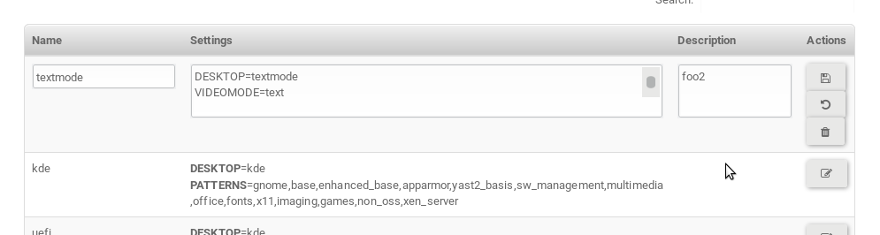

Entering a test suite description in the admin table using the web interface:

If a description is defined, the name of the test suite on the tests overview page shows up as a link. Clicking the link will show the description in a popup. The same syntax as for comments can be used, that is Markdown with custom extensions such as shortened links to ticket systems.

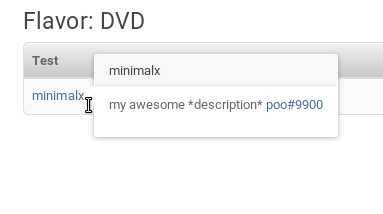

popover in test overview with content as configured in the test suites database:

### 3.3.2 /tests/overview - Customizable test overview page

The overview page is configurable by the filter box. Also, some additional query parameters can be provided which can be considered advanced or experimental. For example specifying no build will resolve the latest build which matches the other parameters specified. Specifying no group will show all jobs from all matching job groups. Also specifying multiple groups works, see the following example.

[figure not shown]

The openQA test overview page showing multiple groups at once. The URL query parameters specify the groupid parameter two times to resolve both the "opensuse" and "opensuse test" group.

Specifying multiple groups with no build will yield the result for the latest build of each group. This can be useful to have a static URL for bookmarking.

### 3.3.3 Review badges

Based on comments in the individual job results for each build a certificate icon is shown on the group overview page as well as the index page to indicate that every failure has been reviewed, e.g. a bug reference or a test issue reason is stated:

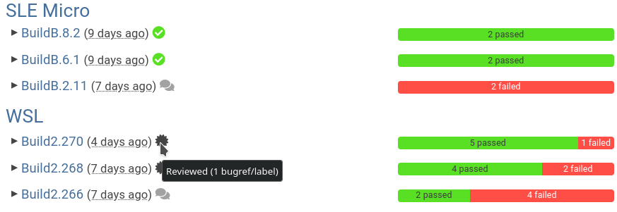

#### 3.3.3.1 Meaning of the different colors

- No icon is shown if at least one failure still need to be reviewed.
- The green tick icon shows up when there is no work to be done.
- The black certificate icon is shown if all review work has been done.
- The grey comment icon is shown if all failures have at least one comment.

(To simplify, checking for false-negatives is not considered here.)

### 3.3.4 Bug references, labels and flags

#### 3.3.4.1 Bug references

It is possible to reference a bug by writing `<bugtracker_shortname>#<bug_nr>` in a comment, e.g. `bsc#1234`. It is also possible to spell out the full URL, e.g. `https://bugzilla.suse.com/show_bug.cgi?id=1234` which will then be shortened automatically. A bug reference is rendered as link and a bug icon is displayed for the job in various places as shown in the figure below. A comment containing a bug reference will also be carried over to reduce manual review work. Refer to the Flags section below for other ways to trigger automated comment carryover.

> **WARNING:** If you want to reference a bug without making it count as a bug reference you need to wrap it into a label (see subsequent section), e.g. `label:bsc#1234`.

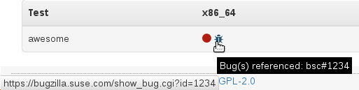

Bug icon for job with bug reference on test result overview

All bug references are stored within the internal database of openQA. The status can be updated using the `/bugs` API route with external tools. One can set the bug status this way which will then be shown in the web UI, see the figure below.

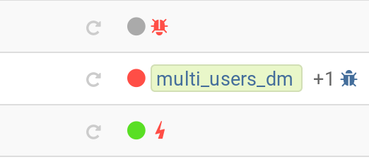

Example for visualization of closed issues: The upside down icons in red visualize closed issues.

> **NOTE:** Also GitHub pull requests and issues can be linked. Use the generic format `[#<project/repo>](marker)#<id>`, e.g. [`gh#os-autoinst/openQA#1234`](https://github.com/os-autoinst/openQA/issues/1234).

#### 3.3.4.2 Labels

A comment can also contain labels. Use `label:<keyword>` where `<keyword>` can be any valid character up to the next whitespace, e.g. `false_positive`. A label is rendered as yellow box. The keywords are not defined within openQA itself. A valid list of keywords should be decided upon within each project or environment of one openQA instance. If a job has a label a special icon will be shown next to it in various places as shown in the figure below.

[figure not shown]

Label icon for job with a label on test result overview

> **NOTE:** A label containing a bug reference will still be treated as a label, not a bugref. The bugref will still be rendered as a link. That means no bug icon is shown and the comment does **not** become subject to carry over.

##### 3.3.4.2.1 Overwrite result of job

One special label format is available which allows to forcefully overwrite the result of an openQA job using a convenient openQA comment. The expected format is `label:force_result:[:<description>](new_result)`, for example `label:force_result:failed` or `label:force_result:softfailed:bsc#1234`. For this command to be effective the according user needs to have at least operator permissions.

> **NOTE:** `force_result`-labels are evaluated when when a comment is carried over. However, the carry over will only happen when the comment **also** contains a bug reference or `flag:carryover`.

#### 3.3.4.3 Flags

Currently there is only one flag for job comments supported.

##### 3.3.4.3.1 flag:carryover

Adding `flag:carryover` to a comment, will result in this comment being carried over to a new job failing for the same reason, without a bugref required.

### 3.3.5 Distinguish product and test issues bugref [gh#708](https://github.com/os-autoinst/openQA/pull/708)

"progress.opensuse.org" is used to track test issues, bugzilla for product issues, at least for SUSE/openSUSE. openQA bugrefs distinguish this and show corresponding icons

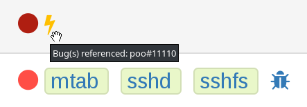

### 3.3.6 Build tagging

#### 3.3.6.1 Tag builds with special comments on group overview

Based on comments on the group overview individual builds can be tagged. As 'build' by themselves do not own any data the job group is used to store this information. A tag has a build to link it to a build. It also has a type and an optional description. The type can later on be used to distinguish tag types. Note that openQA does not define further tag types besides the *important* tag. However, the user is free to choose any tag type as needed.

The generic format for tags is

```
tag:<build_id>:[:<description>](type), e.g. tag:1234:important:Beta1.
```

The `build_id` should be set to the `BUILD` setting of the jobs (**without** the `Build`-prefix shown in dashboard pages). It is also possible to include the `VERSION` setting which then needs to be prepended and separated by a dash (e.g. `tag:15-SP5-25.1:important:Alpha-202210-1` where `15-SP5` is the `VERSION` and `25.1` the `BUILD`). The more recent tag always wins. Tags specifying the `VERSION` as well win over generic tags.

A 'tag' icon is shown next to tagged builds together with the description on the group_overview page. The index page does not show tags by default to prevent a potential performance regression. Tags can be enabled on the index page using the corresponding option in the filter form at the bottom of the page.

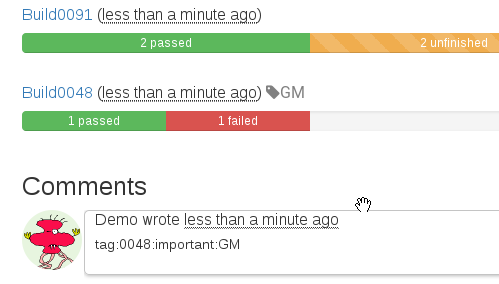

#### 3.3.6.2 Keeping important builds

As builds can now be tagged we come up with the convention that the 'important' type - the only one for now - is used to tag every job that corresponds to a build as 'important' and keep the logs for these jobs longer so that we can always refer to the attached data, e.g. for milestone builds, final releases, jobs for which long-lasting bug reports exist, etc.

### 3.3.7 Filtering test results and builds

At the top of the test results overview page is a form which allows filtering tests by result, architecture and TODO-status. "TODO" means that tests still require review.

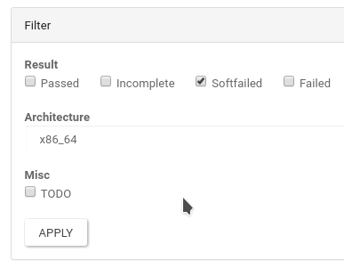

There is also a similar form at the bottom of the index page which allows filtering builds by group and customizing the limits. Also the 'All tests' table allows filtering by the TODO-status.

### 3.3.8 Highlighting job dependencies in 'All tests' table

When hovering over the branch icon after the test name children of the job will be highlighted blue and parents red. So far this only works for jobs displayed on the same page of the table.

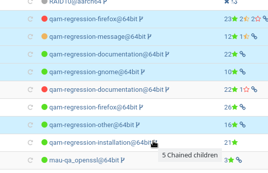

### 3.3.9 Show previous results in test results page [gh](https://github.com/os-autoinst/openQA/pull/538)

On a tests result page there is a tab for "Next & previous results" showing the result of test runs in the same scenario. This shows next and previous builds as well as test runs in the same build. This way you can easily check and compare results from before including any comments, labels, bug references (see next section). This helps to answer questions like "Is this a new issue", "Is it reproducible", "has it been seen in before", "how does the history look like".

Querying the database for former test runs of the same scenario is a rather costly operation which we do not want to do for multiple test results at once but only for each individual test result (1:1 relation). This is why this is done in each individual test result and not for a complete build.

Related issue: https://progress.opensuse.org/issues/10212

Screenshot of the feature:

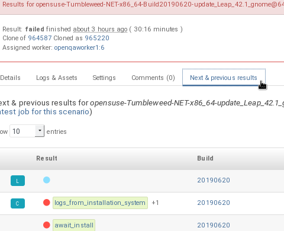

### 3.3.10 Link to latest in scenario name [gh](https://github.com/os-autoinst/openQA/pull/836)

Find the always latest job in a scenario with the link after the scenario name in the tab "Next & previous results" Screenshot:

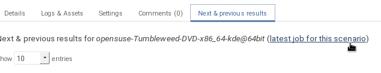

### 3.3.11 Add `latest' query route [gh](https://github.com/os-autoinst/openQA/pull/815)

Should always refer to most recent job for the specified scenario.

- have the same link for test development, i.e. if one retriggers tests, the person has to always update the URL. If there would be a static URL even the browser can be instructed to reload the page automatically
- for linking to the always current execution of the last job within one scenario, e.g. to respond faster to the standard question in bug reports "does this bug still happen?"

Examples:

- `tests/latest?distri=opensuse&version=13.1&flavor=DVD&arch=x86_64&test=kde&machine=64bit`
- `tests/latest?flavor=DVD&arch=x86_64&test=kde`
- `tests/latest?test=foobar` - this searches for the most recent job using test_suite `foobar' covering all distri, version, flavor, arch, machines. To be more specific, add the other query entries.

### 3.3.12 Allow group overview query by result [gh](https://github.com/os-autoinst/openQA/pull/531)

This allows e.g. to show only failed builds. Could be included like in http://lists.opensuse.org/opensuse-factory/2016-02/msg00018.html for "known defects".

Example: Add query parameters like `…&result=failed&arch=x86_64` to show only failed for the single architecture selected.

### 3.3.13 Add web UI controls to select more builds in group_overview [gh](https://github.com/os-autoinst/openQA/pull/804)

The query parameter `limit_builds' allows to show more than the default 10 builds on demand. Just like we have for configuring previous results, the current commit adds web UI selections to reload the same page with higher number of builds on demand. For this, the limit of days is increased to show more builds but still limited by the selected number.

Example screenshot:

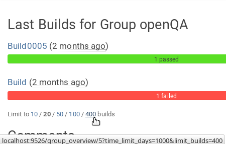

### 3.3.14 More query parameters for configuring last builds [gh](https://github.com/os-autoinst/openQA/pull/575)

By using advanced query parameters in the URLs you can configure the search for builds. Higher numbers would yield more complex database queries but can be selected for special investigation use cases with the advanced query parameters, e.g. if one wants to get an overview of a longer history. This applies to both the index dashboard and group overview page.

Example to show up to three week old builds instead of the default two weeks with up to 20 builds instead of up to 10 being the default for the group overview page:

```
http://openqa/group_overview/1?time_limit_days=21&limit_builds=20
```

### 3.3.15 Web UI controls to filter only tagged or all builds [gh](https://github.com/os-autoinst/openQA/pull/807)

Using a new query parameter `only_tagged=[0|1]' the list can be filtered, e.g. show only tagged (important) builds.

Example screenshot:

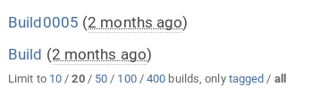

Related issue: https://progress.opensuse.org/issues/11052

### 3.3.16 Test result badges [gh](https://github.com/os-autoinst/openQA/pull/5022)

For build results or individual job results including the latest job result page, there is a corresponding route to get an SVG status badge that can e.g. be used to build a status dashboard or for showing the status within a GitHub comment.

```
http://openqa/tests/123/badge
http://openqa/tests/latest/badge
http://openqa/tests/overview/badge?distri=opensuse&groupid=1&result=not_ok
```

The first two routes refer to a specific job or the latest job of a scenario. The `/tests/overview/badge` route summarizes the status of multiple jobs based on overview query parameters, reflecting the most critical status (e.g. `failed`). It supports the same query parameters as the overview page.

There is an optional parameter `show_build=1` that will prefix the status with the build number (or `multi` if multiple builds are targeted). The parameter `label` can be used to set a custom label on the left side of the badge (instead of the default `openQA`). When a custom label is used, the openQA logo is omitted to provide more space for the text.

### 3.3.17 Build a continuous openQA monitoring dashboard

With just some common tools a dashboard showing the openQA index page with continuously updated results can be setup. Example setup using the `fullscreen=1` parameter to use the entire page for the build results:

Content of /home/tux/.xinitrc

```bash
#!/bin/bash

unclutter &
openbox &
xset s off
xset -dpms
sleep 5
url="https://openqa.opensuse.org?group=openSUSE Tumbleweed\$|openSUSE Leap [0-9]{2}.?[0-9]*\$|openSUSE Leap.\*JeOS\$|openSUSE Krypton|openQA|GNOME Next&limit_builds=2&time_limit_days=14&&show_tags=1&fullscreen=1#build-results"
chromium --kiosk "$url" &

while sleep 300 ; do
        xdotool windowactivate $(xdotool search --class Chromium)
        xdotool key F5
        xdotool windowactivate $(xdotool getactivewindow)
done
```

Content of /usr/share/lightdm/lightdm.conf.d/50-suse-defaults.conf

```
[Seat:*]
pam-service = lightdm
pam-autologin-service = lightdm-autologin
pam-greeter-service = lightdm-greeter
xserver-command=/usr/bin/X
session-wrapper=/etc/X11/xdm/Xsession
greeter-setup-script=/etc/X11/xdm/Xsetup
session-setup-script=/etc/X11/xdm/Xstartup
session-cleanup-script=/etc/X11/xdm/Xreset
autologin-user=tux
autologin-timeout=0
```

### 3.3.18 Carry over of bug references from previous jobs in same scenario

Many test failures within the same scenario might be due to the same reason. To avoid human reviewers having to add the same bug references again and again, bug references are carried over from previous failures in the same scenario if a job fails. The same behaviour can be achieved by adding `flag:carryover` to a comment. This idea is inspired by the [Claim plugin](https://wiki.jenkins-ci.org/display/JENKINS/Claim+plugin) for Jenkins.

> **NOTE:** The carry-over feature works on test module level. Only if the same set of test module as in a predecessor job fails the latest bug reference is carried over.

> **NOTE:** The lookup-depth is limited. The search for candidates will also stop early if too many different kinds of failures were seen. Check out the descriptions of the relevant settings in the `carry_over` section of the web UI configuration for details.

> **NOTE:** For an approach to add bug references based on a search expression found in the job reason for incomplete jobs or job logs consider Enabling custom hook scripts on "job done" based on result.

> **NOTE:** To keep the carry-over of independent submissions (e.g. pull-requests) apart despite otherwise equal scenario keys, use history isolation keys.

### 3.3.19 Pinning comments as group description

This is possible by adding the keyword `pinned-description` anywhere in a comment on the group overview page. Then the comment will be shown at the top of the group overview page. However, it only works as operator or admin.

### 3.3.20 Dark mode

A dark mode theme can be enabled via "Appearance" settings for all logged in users. It can either be forced with the "dark mode" setting, or left to browser detection. Switching automatically between light and dark mode is natively supported by most modern browsers and can also be controlled manually via flags:

- On Firefox, go to `about:preferences#general` and search for "Website appearance". - On Chrome, go to `chrome://flags/` and search for "Dark mode".

For more information, see [developer](https://developer.mozilla.org/en-US/docs/Web/CSS/@media/prefers-color-scheme)

### 3.3.21 Developer mode

The developer mode allows to:

- Create or update needles from `assert_screen` mismatches ("re-needling")
- Pause the test execution (at a certain module) for manual investigation of the SUT

It can be accessed via the "Live View" tab of a running test. Only registered users can take control over tests. Basic instructions and buttons providing further information about the different options are already contained on the web page itself. So I am not repeating that information here and rather explain the overall workflow.

In case the developer mode in not working on your instance, try to follow the steps for debugging the developer mode under 'Pitfalls'.

#### 3.3.21.1 Workflow for creating or updating needles

1. In case a new needles should be created, add the corresponding `assert_screen` calls to your test.
2. Start the test with the `assert_screen` calls which are supposed to fail. 3. Select "`assert_screen` timeout" under "Pause on screen mismatch" and confirm.
3. Wait until the test has paused. There is a button to skip the current timeout to speed this up.
4. A button for accessing the needle editor should occur. It may take a few seconds till it occurs because the screenshots created so far need to be uploaded from the worker to the web UI. Of course it is also possible to go back to the "Details" tab to create a new needle from any previous screenshot/match available.
5. After creating the new needle, click the resume button to test whether it worked.

Steps 4. to 6. can be repeated for further needles without restarting the test.

### 3.3.22 Job group editor [gh](https://github.com/os-autoinst/openQA/pull/2111)

Scenarios are defined as part of a job group. The `Edit job group` button exposes the editor.

#### 3.3.22.1 YAML job templates editor

Settings can be specified as a key/value pair for each scenario. There is no equivalent in the table view so you need to migrate groups to use this feature.

Any settings specified on test suites, machines or products are also used and can still be modified independently. However, the YAML document should be updated before renaming or deleting test suites, products or machines used by it, otherwise that would create an inconsistent state.

Job groups can be updated through the YAML editor or the YAML-related REST API routes.

#### 3.3.22.2 Deprecated: Table-based (pre-migration)

In old versions openQA had a table-based UI for defining job templates, listed in a table per medium. Machines can be added by selecting the architecture column and picking a machine from the list. Remove scenarios by removing all of their machines. Add new scenarios via the blue Plus icon at the top of the table. Changes to the priority are applied immediately.

If job groups still exist showing the old mode, the `Edit YAML` button can be used to reveal the YAML editor and migrate a group. After saving for the first time, the group can only be configured in YAML. The table view will not be shown anymore.

Note that making a backup before migrating groups may be a good idea, for example using `openqa-dump-templates`.

To migrate an old job group using the API the current schedule can be retrieved in YAML format and sent back to save as a complete YAML document. For example for all job groups in the old format:

```bash
for i in $(ssh openqa.example.com "sudo -u geekotest psql --no-align --tuples-only --command=\"select id from job_groups where template is null order by id;\" openqa") ; do
    curl -s http://openqa.example.com/api/v1/job_templates_scheduling/$i | openqa-cli api --host http://openqa.example.com -X POST job_templates_scheduling/$i schema=JobTemplates-01.yaml template="$(cat -)"
done
```

Note that in some cases you might run into errors where old test suites or products have invalid names which the old editor did not enforce:

**Product names** may not contain `:` or `@` characters. Something like `Server-DVD-Staging:A` would require replacing the `:` with eg. a `-`.

**Test suites** may not contain `:` or `@` characters. A test suite such as `ext4_uefi@staging` would have been allowed previously. The use of the `@` as a suffix could be replaced with a `-` or if it is used for variants of the same test suite with different settings, settings can be specified in YAML directly.

More generally the regular expression `[A-Za-z0-9._*-]+` could be used to check if a name is allowed for a product or test suite.

## 3.4 Configuring job groups via YAML documents

A new job group starts out empty, which in YAML means that the two mandatory sections are present but contain nothing. This is what can be seen when editing a completely group, and what is also the state to revert to before deleting a job group that is no longer useful:

```yaml
products: {}
scenarios: {}
```

A job group is comprised of up to three main sections. `products` defines one or more mediums to run the scenarios in the group. At least one needs to be specified to be able to run tests. Going by an example of openSUSE 15.1 the name, distri, flavor and version could be written like so. Note that the version is a string in single quotes.

```yaml
products:
  opensuse-15.1-DVD-Updates-x86_64:
    distri: opensuse
    flavor: DVD-Updates
    version: '15.1'
```

To complete the job group at least one scenario has to be added. A scenario is a combination of a test suite, a machine and an architecture. Scenarios must also be unique across job groups - trying to add it to multiple job groups is an error. Case in point, `textmode` and `gnome` could be defined like so:

```yaml
scenarios:
  x86_64:
    opensuse-15.1-DVD-Updates-x86_64:
      - textmode
      - gnome:
          machine: uefi
          priority: 70
          settings:
            QEMUVGA: cirrus
```

### 3.4.1 Defaults

Now there are two scenarios for `x86_64`, one by giving just the name of the test suite and another which has a machine, priority and settings. Both are allowed. However since at least one scenario relies on defaults those need to be specified once in their own section:

```yaml
defaults:
  x86_64:
    machine: 64bit
    priority: 50
```

The defaults section is only required whenever a scenario is not completely defined in-place. When it is used, the available parameters are identical to those for a single scenario. For instance the example could be amended to use settings and run every test suite for that architecture on several machines by default.

```yaml
defaults:
  x86_64:
    machine: [64bit, 32bit]
    priority: 50
    settings:
      FOO: '1'
```

Defaults are always overwritten by explicit parameters on scenarios. Further more, all settings can be specified in YAML. Using this together with custom job template names, variants of a scenario can even be specified when they would normally be considered duplicated:

```yaml
scenarios:
  x86_64:
    opensuse-15.1-DVD-Updates-x86_64:
      - textmode
      - gnome:
          machine: uefi
          priority: 70
          settings:
            QEMUVGA: cirrus
      - gnome_staging:
          testsuite: gnome
          machine: [32bit, 64bit-staging]
          settings:
            FOO: '2'
```

### 3.4.2 YAML Aliases

Even more flexibility can be achieved by using aliases in YAML, or in other words reusing a scenario by reference, such as to run the same scenarios in two different mediums. `&` is used to define an anchor, while `*` is the alias referencing the anchor:

```yaml
products:
  opensuse-15.1-DVD-Updates-x86_64:
    distri: opensuse
    flavor: DVD-Updates
    version: '15.1'
  opensuse-15.2-GNOME-Live-x86_64:
    distri: opensuse
    flavor: GNOME-Live
    version: '15.2'
scenarios:
  x86_64:
    opensuse-15.1-DVD-Updates-x86_64:
      - textmode
      - gnome: &gnome
          machine: uefi
          priority: 70
          settings:
            QEMUVGA: cirrus
      - gnome_staging: &gnome_staging
          testsuite: gnome
          machine: [32bit, 64bit-staging]
          settings:
            FOO: '2'
    opensuse-15.2-GNOME-Live-x86_64:
      - textmode
      - gnome: *gnome
      - gnome_staging: *gnome_staging
```

### 3.4.3 YAML Merge Keys

Also [YAML Merge Keys](https://yaml.org/type/merge.html) are supported. This way you can reuse previously defined anchors and add other values to it. Values in the merged alias will be overridden.

You can even merge more than one alias.

```yaml
products:
  opensuse-15.1-DVD-Updates-x86_64:
    distri: opensuse
    flavor: DVD-Updates
    version: '15.1'
  opensuse-15.2-GNOME-Live-x86_64:
    distri: opensuse
    flavor: GNOME-Live
    version: '15.2'
scenarios:
  x86_64:
    opensuse-15.1-DVD-Updates-x86_64:
      - textmode
      - gnome:
          machine: uefi
          priority: 70
          settings: &common1
            QEMUVGA: cirrus
            FOO: default foo
      - gnome:
          machine: [32bit, 64bit-staging]
          priority: 70
          settings: &common2
            QEMUVGA: cirrus
            FOO: default foo
            BAR: default bar
      - gnome_staging:
          testsuite: gnome
          machine: [32bit, 64bit-staging]
          settings:
            # Merge
            <<: *common1
            FOO: foo # overrides the value from the merge keys
      - gnome_staging:
          testsuite: gnome
          machine: [32bit, 64bit-staging]
          settings:
            # Merge
            <<: [*common1, *common2] # *common1 overrides *common2
            FOO: foo # overrides the value from the merge keys
```

### 3.4.4 General YAML documentation

The job templates are written in [YAML 1.2](https://yaml.org/spec/1.2/spec.html). In YAML, strings usually do not have to be quoted, except if it is a special value that would be loaded as a Boolean, NULL or Number. The following table shows all special values (See the documentation for the default [YAML 1.2 Core Schema](https://yaml.org/spec/1.2/spec.html#id2804923) for more information).

| Type | Special Values |
| --- | --- |
| `bool` | `true` `\|` `True` `\|` `TRUE` `\|` `false` `\|` `False` `\|` `FALSE` |
| `int` `(Base` `8)` | `0o7`, `0o10`, `0o755` Regular Expression: `0o` [0-7](code)+ |
| `int` `(Base` `10)` | `23`, `+42`, `0123`, `-314` Regular Expression: [-](code)? [0-9](code) |
| `int` `(Base` `16)` | `0xFF`, `0xa`, `0xc0ffee` Regular Expression: `0x` [0-9a-fA-F](code)+ |
| `float` `(Number)` | `3.14`, `+3.14`, `-3.14`, `3.3e+3`, `3.3e3`, `.14`, `001.23`, `.3E-1`, `3e3` Regular Expression: [-](code)? `(` `\.` [0-9](code) `\|` [0-9](code)+ `(` `.` [0-9](code)* `)?` `)` `(` [eE](code) [-](code… |
| `float` `(Infinity)` | `.inf`, `+.inf`, `-.inf`, `.Inf` etc. Regular Expression: [-+](code)? `.` `(` `inf` `\|` `Inf` `\|` `INF` `)` |
| `float` `(Not` `a` `number)` | `.nan`, `.NaN`, `.NAN` Regular Expression: `.` `(` `nan` `\|` `NaN` `\|NAN` `)` |
| `null` | `null` `\|` `Null` `\|` `NULL` `\|` `~` `\|` `#` `empty` |
| `str` | everything else |

Because we are using the Merge Keys feature, also the unquoted string `<<` is special. If you need the literal string `<<` (for example as a value in the job settings), you have to quote it.

## 3.5 Reserving workers

Operators can reserve individual worker instances to take them out of the scheduling rotation, for example for maintenance or manual testing. Reserving a worker does not interrupt the job it is currently running, it only prevents new jobs from being assigned. A reservation expires automatically after its duration, releasing the worker again.

Reservations are managed in the workers table of the admin area or via the more convenient `reservation` subcommand of `openqa-cli`. The worker can be specified either by its database ID or its `<host>:<instance>` identifier:

```bash
openqa-cli reservation --comment="Manual testing" --duration=5h <id>
# Or by host and instance format:
openqa-cli reservation --comment="Manual testing" --duration=5h openqa-worker1:1
openqa-cli reservation --release <id>
```

Alternatively, reservations can be managed via the REST API directly using either identifier:

```bash
openqa-cli api -X POST workers/<id>/reservation comment="Manual testing" duration=5h
openqa-cli api -X POST workers/<host>:<instance>/reservation comment="Manual testing" duration=5h
openqa-cli api -X DELETE workers/<id>/reservation
```

The duration accepts a plain number of seconds or a value with a unit suffix such as `30m`, `5h` or `2d`. Only admins may use `0` for an indefinite reservation, override a reservation held by somebody else via `force=1` or release a reservation owned by somebody else.

The comment requirement, the default duration and the maximum durations for operators and admins are configured in the `[worker_reservation]` section of `/etc/openqa/openqa.ini`.

### 3.5.1 Keeping a reserved worker usable for specific tasks

By default, a reserved worker is completely excluded from scheduling. If you need to run specific jobs on it (e.g. to test a worker configuration change), you can assign it a specific class when reserving it:

```bash
openqa-cli reservation --class poo167749 --comment "poo#167749 verification" \
  --duration 1d <worker_id>
openqa-clone-job --within-instance openqa.example.com 12345 WORKER_CLASS=poo167749
openqa-cli reservation --release <worker_id>
```

The effective class set of the worker becomes its normal capability classes (like `qemu_x86_64`) plus the specific class, meaning that the specific class is appended to the existing comma-separated list of worker classes. However, contrary to normal operation, the worker will only match jobs that explicitly request this specific class. This mechanism replaces editing `WORKER_CLASS` in `workers.ini` because it is instant, requires no worker restart, is not reverted by configuration management, and the state is visible in the web UI.

A worker reserved this way still counts as reserved rather than idle in the overall statistics. Reservations are tracked per web UI, so a worker connected to multiple web UIs is only tagged on the one where the reservation was made.

### 3.5.2 Reserving complete worker hosts

Complete physical worker hosts can be reserved atomically for maintenance or configuration updates, taking all of their worker instances out of rotation in one action. This avoids the manual effort of reserving dozens of slots individually and eliminates race conditions.

```bash
openqa-cli reservation --worker-host=worker01.infra.opensuse.org --comment="Kernel update" --duration=5h
openqa-cli reservation --worker-host=worker01.infra.opensuse.org --release
```

- **Symmetric all-or-nothing semantics**: Host reservation is atomic. If any worker instance on the host is already reserved by another user, the operation fails with a 409 Conflict identifying the conflicting instances. Admins can override this with the `--force` option.
- **Inheritance on worker registration**: When worker instances restart, reconnect, or newly register, they automatically inherit any active host-level reservation from their sibling instances on the same host. This prevents fresh slots from picking up production jobs during a machine's maintenance window.
- **Verification mode support**: Just like individual reservations, you can supply `--class` to a whole-host reservation to place the entire machine into verification mode for testing host-level changes:

```bash
openqa-cli reservation --worker-host=worker01.infra.opensuse.org --class=poo167749 --comment="poo#167749 host verification" --duration=1d
```

### 3.5.3 Worker host administration

Clicking on any host name in the workers table or a worker's detail page navigates to the joint host administration view (`/admin/worker_hosts/<host>`). This view aggregates:

- **Aggregated host health**: Statistics on online, busy, idle, reserved, and dead worker instances.
- **Joint configuration**: Consolidated properties comparing and highlighting identical vs. different configuration parameters across all instances.
- **Aggregated job history**: A combined DataTable of previous jobs executed across all worker slots on the machine.